# Model 3: Sex-Stratified Models

Sections 5.9 and 5.10 implemented in ten reviewable steps

Author

Analysis Team

Published

August 3, 2026

# Mission — `model-3`

Model 1 asked “what predicts absence among Canadian workers?” and answered it once. Model 2 asked it seventeen more times, once inside each chronic-condition subgroup. Model 3 asks it twice — once among female respondents and once among male respondents — which is what Section 5.9 requests. It is a self-contained estimation script: it reads the Ellis parquet, builds its own frames, runs its own selection, and persists its own evidence. Nothing in it is loaded from model-1 or model-2.

What it borrows from both is *shape*. The same ten steps, the same artifact roles — `t6` is the deliverable table, `t62` the full ledger, `t61` the in-sample metrics, `t63` and `t64` the held-out ones, `t7` the manifest — and the same helper functions under the same names. A reader who has read either predecessor should be able to read this one without relearning anything.

One thing genuinely differs, and it is the reason model-3 exists as a separate script rather than as a re-run of model-1 on two subsets. Section 5.9 asks not only for two models but for the **difference** between them: the stratification is there to “highlight potential differences in the determinants of absenteeism between men and women.” Two selected models cannot supply that difference cleanly, because a term absent from one of them may be absent because the association is absent, or because a penalty declined to select it — and the output does not distinguish the two. Artifacts `t65`, `g5` and `g51` answer the comparison question on a *union model* instead, and Step 8 explains why.

**This report is built to be vetted, not merely read.** As in model-1 and model-2, it is organised as ten steps, each closing with a *review point* naming exactly what a reader should agree or disagree with before the next step is allowed to stand.

**The status of these estimates**

Model 3 is the **definitive estimation script for Sections 5.9 and 5.10**. The fitted objects, coefficient ledgers, and fold-level metrics it writes to disk are the versioned evidentiary record for those sections. Downstream reports should read those artifacts and interpret them; they should not re-estimate. Step 10 lists every artifact with the call that reloads it.

Three caveats travel with every number here and cannot be removed by re-running anything:

1. **The intervals are not the intervals the proposal asked for.** Bootstrap replicate weights do not exist in the 2010 or 2014 PUMF (inherited decision 10). Three interval variants are reported instead, two of which are explicit lower bounds on the understatement.
2. **Estimation and selection used the same stratum.** The rate ratios in Step 8 are conditional on a procedure that consumed the whole stratum. Step 9 measures how much that flatters them.
3. **The female–male comparison in Table t65 is a screen, not a set of confirmatory tests.** It carries no multiplicity control, and every row inherits the selection step that produced the union term set.

**Research questions:**

1. What does Section 5.9 mean by “female” and “male” in files that carry a binary sex item and no gender item, and what follows from that for how this report may be worded?
2. Do the two strata differ in *composition* before any model is fitted, and by enough to confound a later difference in what the penalty selects?
3. What does the Section 5.4 LASSO procedure retain inside each stratum, and do the two strata retain the same things?
4. What is the adjusted prevalence rate ratio for every retained term in every stratum, and how wide is the interval once the missing bootstrap is accounted for?
5. Where do the female and male associations genuinely differ, as distinct from where the two selections happened to disagree?
6. How well does each sex-stratified model predict on respondents it has not seen, and how stable is its selected variable list when a fifth of a stratum is withheld?

# Definition of Terms

**Stratum.** The set of respondents of one sex within the model-1 complete-case frame. The two strata are disjoint and exhaustive: together they *partition* the Section 5.5 analytic sample, so every respondent in Table 3 appears in exactly one row-block of Table 5. This is the structural difference from model-2, whose seventeen subgroups overlapped heavily.

**Sex, not gender.** The PUMF carries `DHH_SEX`, a binary item, in both cycles. Neither cycle carries a gender-identity question. The report says *sex* throughout and does not use the two words interchangeably. Decision 31 records this; it is a property of the instrument, not a modelling choice.

**Stratification as interaction.** Fitting the model separately by sex allows *every* coefficient to differ between the sexes, including the dispersion parameter. A single set of sex-by-term interactions in a pooled model would allow only the chosen terms to differ. Stratification is therefore the more permissive of the two, which is why no interactions are introduced on top of it (decision 33).

**Union model.** A negative binomial model fitted, without penalty, on the union of the terms *either* stratum retained under the primary specification — then fitted separately in each stratum. It is the basis of the female–male comparison (decision 39). Its purpose is to guarantee that every term has an estimate on both sides, so that “not selected” is never read as “null.”

**Ratio of rate ratios.** The female rate ratio divided by the male one, for the same term in the union model. A value of 1 means the association is identical in the two strata. Its interval and $z$-test use $\mathrm{se} = \sqrt{\mathrm{se}_F^2 + \mathrm{se}_M^2}$, which is valid precisely because the two strata are disjoint samples.

**`lambda.min` / `lambda.1se`.** The penalty minimising cross-validated deviance, and the largest penalty whose deviance remains within one standard error of that minimum. Section 5.5 designates the second as primary. Model 2 reversed that designation for small subgroups; model-3 does *not* adopt the reversal, and decision 35 says why.

**Unstable term.** A term whose standard error exceeds 2 on the log scale, meaning its rate-ratio interval spans more than four orders of magnitude. Such terms are marked rather than removed; their point estimates should not be quoted.

**Standardised difference.** For a design column, the female-minus-male difference in weighted means divided by the pooled standard deviation. It is used in Step 2 to describe how far the two strata differ in composition, before any model is fitted.

**Held out.** Computed on respondents the model was not fitted to. Section 5.10 asks for held-out error explicitly, and it is not the same quantity as the in-sample error a single fit reports.

# Environment

**Packages used in the current report**

```r
library(magrittr)
library(ggplot2)
library(dplyr)
library(tidyr)
library(forcats)
library(purrr)
library(tibble)
library(scales)
library(fs)
library(kableExtra)
requireNamespace("arrow", quietly = TRUE)
requireNamespace("glmnet", quietly = TRUE)
requireNamespace("MASS", quietly = TRUE)
requireNamespace("readr", quietly = TRUE)
requireNamespace("knitr", quietly = TRUE)
requireNamespace("survival", quietly = TRUE) # concordance() for the Section 5.10 C-statistic
```

**Project functions and Alberta visual identity colours**

```r
base::source("./scripts/common-functions.R")
base::source("./scripts/graphing/graph-presets.R")
```

**Paths, seed, the stratification variable, the four specifications, and the decision registry**

```r
local_root <- "./analysis/model-3/"
local_data <- paste0(local_root, "data-local/")
fits_folder <- paste0(local_data, "fits/")
prints_folder <- paste0(local_root, "prints/")
path_parquet <- "./data-private/derived/cchs-2-tables/cchs_analytic.parquet"

outcome_var <- "days_absent_total"
weight_col <- "wts_m_pooled"
cycle_var <- "cchs_cycle_f"
forced_vars <- cycle_var
lasso_seed <- 42
lasso_folds <- 5

# The stratification variable of Section 5.9. The PUMF carries DHH_SEX, a binary
# item; there is no gender-identity question in either the 2010 or the 2014
# cycle. Decision 31.
stratum_var <- "sex"

# Section 5.9 names the female model first, so it is reported first, even though
# the Ellis factor orders Male before Female.
strata_levels <- c("Female", "Male")

# Section 5.10 performance cross-validation. Named apart from `lasso_folds` for
# the same reason as in model-1 and model-2: that one tunes the penalty inside
# glmnet on a Poisson deviance, this one estimates out-of-sample prediction
# error for the negative binomial refits. Both are five-fold because Sections
# 5.4 and 5.10 both say five; they are not the same folds.
perf_folds <- 5
perf_seed <- 42

# A term whose standard error exceeds this on the log scale has an interval
# spanning more than four orders of magnitude on the rate-ratio scale. It is
# reported and marked rather than removed. Decision 40.
unstable_se <- 2

# Step 9 refits every specification on every fold twice over, for both strata,
# so the block is cached. Set TRUE to rebuild.
force_refit_cv <- FALSE
cv_cache_path <- paste0(fits_folder, "cv-performance.rds")

for (folder in c(local_data, fits_folder, prints_folder)) {
  if (!fs::dir_exists(folder)) { fs::dir_create(folder, recurse = TRUE) }
}

# The canonical candidate registry, shared with model-0, model-00, model-1 and
# model-2. See scripts/modeling/candidate-registry.R for the full contract.
# What model-3 uses from it:
#   candidate_registry        52 rows, with domain, label and exclusion reason
#   lasso_vars                48; also used to define the complete-case frame
#   vars_excluding_perceived  45; the Section 5.5 primary predictor set
#   vars_including_perceived  48; the Section 5.5 secondary predictor set
base::source("./scripts/modeling/candidate-registry.R")

# The four specifications of Section 5.4, carried in full into each stratum.
# model-2 carried only two, because a condition subgroup of a few hundred
# respondents cannot support the four-way comparison. A sex stratum is roughly
# half the Section 5.5 analytic sample, so that constraint does not apply and
# model-3 answers "the same LASSO procedure described in Section 5.4" literally.
# Decision 34.
#
# Models 1 and 3 share a single cross-validated fit within a stratum, as do
# Models 2 and 4: the predictor set defines the fit, the penalty selects a model
# from it. Two predictor sets x two strata = four cv.glmnet fits in total.
model_specs <- tibble::tribble(
  ~spec_id,  ~model_label, ~perceived_health, ~lambda_rule,  ~fit_id,   ~role,
  "model_1", "Model 1",    "excluded",        "lambda.1se",  "exclude", "Primary",
  "model_2", "Model 2",    "included",        "lambda.1se",  "include", "Secondary",
  "model_3", "Model 3",    "excluded",        "lambda.min",  "exclude", "Sensitivity",
  "model_4", "Model 4",    "included",        "lambda.min",  "include", "Sensitivity"
)

# Section 5.5 designates the 1SE rule without perceived health as primary, and
# Section 5.9 refers selection back to Section 5.4 without amending that
# designation. model-3 therefore keeps model-1's ordering, and does NOT adopt
# model-2's decision 25, which reversed it for small subgroups only.
primary_spec <- "model_1"

fit_ids <- unique(model_specs$fit_id)
candidate_sets <- list(
  exclude = vars_excluding_perceived,
  include = vars_including_perceived
)

# Decisions 1 through 19 are made in model-1 and inherited here unchanged. They
# are listed by title so that model-3 is readable on its own; the alternatives,
# rationale and reversal instructions live in model-1 Table t3 and are not
# restated, because two copies of a decision drift.
#
# Decisions 20 through 30 belong to model-2 and are specific to condition
# subgroups. model-3 does not inherit them. Where one of them describes a device
# model-3 also needs - the unstable-term flag, the within-stratum design effect,
# the two cross-validation variants - model-3 re-makes the decision on its own
# account below, so that changing model-2 cannot silently change model-3.
inherited_decisions <- tibble::tribble(
  ~id, ~decision,                                  ~chosen,
  1L,  "Outcome variable",                         "days_absent_total",
  2L,  "COPD indicator",                           "Exclude",
  3L,  "Family doctor indicator",                  "Exclude",
  4L,  "Age resolution",                           "age_group_3",
  5L,  "Missing data handling",                    "Complete case",
  6L,  "Perceived health definition",              "The 3 self-perceived measures",
  7L,  "Dummy coding scheme",                      "Reference contrasts",
  8L,  "Cycle indicator",                          "Unpenalised (penalty.factor = 0)",
  9L,  "Carry-forward rule to stage 2",            "Any surviving column promotes the whole factor",
  10L, "Variance estimation",                      "Wald standard errors (bootstrap weights absent from the PUMF)",
  11L, "Penalty selection",                        "5-fold CV, seed 42",
  12L, "Weights in cross-validation",              "Weighted likelihood",
  13L, "Child-presence flag dhhgl12",              "Descriptives and bivariate models only",
  14L, "Homeownership",                            "Include DHH_OWN directly as home_ownership",
  15L, "Interval reporting",                       "Wald, sandwich and Kish-inflated, side by side",
  16L, "Basis for the held-out cross-validation",  "Both fixed term set and selection re-run",
  17L, "C-statistic for a count outcome",          "Harrell's C on predicted mean vs observed count",
  18L, "Information criteria under weighting",     "Report with a pseudo-likelihood caveat",
  19L, "Scale of the error metrics",               "Weighted"
)
```

```r
# The decisions model-3 makes on its own account. Numbering continues from
# model-2 so that a decision id is unambiguous across the whole project.
decision_registry <- tibble::tribble(
  ~id, ~decision, ~alternatives, ~chosen, ~rationale, ~reversal,

  31L, "The stratification variable",
  "sex as recorded in DHH_SEX; a gender variable; sex crossed with age or cycle",
  "sex (DHH_SEX), two levels",
  "Section 5.9 says 'female respondents' and 'male respondents'. The PUMF carries DHH_SEX, a binary item, in both cycles, and neither cycle carries a gender-identity question. The report therefore says sex and not gender throughout, and the two-level structure is a property of the instrument rather than a modelling choice. No respondent is excluded by the stratification: DHH_SEX has no missing values in the analytic frame.",
  "`stratum_var` and `strata_levels` in declare-globals",

  32L, "Stratum base sample",
  "Re-derive complete cases inside each stratum; filter the model-1 complete-case frame",
  "Filter the model-1 frame",
  "Re-deriving would give each stratum its own denominator and its own candidate set, so the female and male models would not be comparable with each other and neither would be comparable with Table 3. Filtering makes each stratum a strict subset of the Section 5.5 analytic sample, and makes the two strata a partition of it.",
  "`ds1` in tweak-data-0",

  33L, "Candidate set inside a stratum",
  "Keep sex in the candidate set; remove it; remove it and add its interactions",
  "Remove sex; keep everything else that is informative",
  "Sex is constant inside its own stratum by construction and carries no information there. Nothing else is removed a priori: a variable is dropped only if it loses all but one level inside the stratum, and every such drop is recorded in Table t2. Interactions are not introduced, because stratification IS the interaction Section 5.9 asks for - fitting the model separately by sex allows every coefficient to differ, which a single sex-by-term interaction set would only do for the terms chosen to carry it.",
  "`stratum_candidates()` in declare-functions",

  34L, "How many Section 5.4 specifications are carried",
  "One (the Section 5.5 primary); two (one predictor set at both penalties, as model-2 does); all four",
  "All four",
  "Section 5.9 refers selection back to Section 5.4, which describes four specifications on two axes. model-2 carried only the primary predictor set because a condition subgroup of a few hundred respondents cannot support a four-way comparison. A sex stratum is roughly half the Section 5.5 sample, so that constraint does not apply, and carrying all four makes Table 5 comparable with Table 3 specification by specification. Models 1 and 3 share one cross-validated fit and Models 2 and 4 share another, so four specifications cost two fits per stratum, not four.",
  "`model_specs` and `candidate_sets` in declare-globals",

  35L, "Penalty rule designated primary",
  "lambda.1se as Section 5.5 designates; lambda.min as model-2 designates for small subgroups",
  "lambda.1se, without perceived health (Model 1)",
  "model-2 reversed this ordering with decision 25, but the argument there was scale: a parsimonious penalty applied to a subgroup of a few hundred respondents frequently returns nothing at all. In model-1 the 1SE rule retained 10 variables at n = 48,932, and a sex stratum is about half of that, so the rule has something to say. Section 5.5's designation therefore stands unamended. Table t5 reports what each rule retained in each stratum so the choice remains checkable.",
  "`primary_spec` in declare-globals",

  36L, "Design effect basis",
  "Reuse model-1's full-sample Kish design effect; compute one within each stratum",
  "Within each stratum",
  "A design effect describes the weight distribution of the sample whose intervals it widens. Weights inside a sex stratum are not distributed as they are in the pooled sample, and Output out5 shows the realised value differing between the two. This repeats model-2's decision 29 rather than inheriting it, so that the two reports can diverge without either breaking silently.",
  "`build_stratum()` in declare-functions",

  37L, "Weight rescaling",
  "Carry model-1's weight into the stratum unchanged; rescale to mean 1 within each stratum",
  "Rescale within each stratum",
  "glm.nb treats prior weights as frequencies when estimating dispersion, so a stratum whose carried-forward weights average far from 1 would return a theta on a different scale from the other. Rescaling inside the stratum makes theta comparable between the female and male models. Point estimates are unaffected; only the scale of the weights changes.",
  "`build_stratum()` in declare-functions",

  38L, "Section 5.10 resampling method",
  "5-fold cross-validation; leave-one-out; a single train / test split",
  "5-fold, in both variants of inherited decision 16",
  "Section 5.10 names five folds and, unlike Section 5.8, does not offer leave-one-out - which is consistent, because both strata are large. The term set is scored twice over: once held fixed at what the whole stratum selected (Table t63, the literal reading), and once with the entire two-stage procedure re-run inside each training fold (Table t64, the honest estimate). Folds that fail to converge are counted, not silently dropped.",
  "`perf_folds` in declare-globals",

  39L, "Basis for the female-male comparison",
  "Compare the two selected models term by term; compare only terms selected in both; refit both strata on the union of the two selected sets",
  "Refit on the union set",
  "Section 5.9 asks the stratified models to 'highlight potential differences in the determinants of absenteeism between men and women'. Comparing the two SELECTED models cannot do that cleanly: a term missing from the male model may be absent because the association is absent, or because a penalty declined to select it, and the two are not distinguishable from the output. Refitting both strata, without penalty, on the union of the terms either stratum retained under the primary specification gives every term an estimate on both sides. Selection asymmetry is then reported separately, as a fact about the procedure, in the 'Retained in' column of Table t65.",
  "`union_terms` and `nb_union` in the t65 block",
```

```r
  40L, "Rare levels and unstable terms",
  "Collapse rare levels; drop variables that have a rare level; retain and flag",
  "Retain and flag at SE > 2 on the log scale",
  "The same device model-2 adopted with decision 27, re-made here rather than inherited. It matters much less at stratum scale than at subgroup scale - both strata carry more than twenty thousand respondents - but a factor level that is rare in the population is rare in both strata, and a flagged term is cheaper than a silently uninformative interval.",
  "`unstable_se` in declare-globals"
)

domain_colours <- c(
  "Exposure"      = abcol[["magenta"]],
  "Predisposing"  = abcol[["blue"]],
  "Facilitating"  = abcol[["green"]],
  "Needs"         = abcol[["brown"]],
  "Survey design" = abcol[["grey"]]
)

stratum_colours <- c(
  "Female" = abcol[["magenta"]],
  "Male"   = abcol[["blue"]]
)
```

**Helpers for stratum construction, penalised fitting, and negative binomial refitting**

```r
# Render a data frame as styled HTML for Quarto, or plainly for console use.
# Tall tables get a fixed-height scroll box so the report stays navigable.
print_table <- function(data, caption, align = NULL, scroll_height = NULL) {
  if (is.null(scroll_height) && nrow(data) > 25) scroll_height <- "600px"
  boxed <- data %>%
    knitr::kable(
      format = "html", caption = caption, escape = FALSE,
      align = align, row.names = FALSE
    ) %>%
    kableExtra::kable_styling(
      bootstrap_options = c("striped", "hover", "condensed"), full_width = FALSE
    )
  boxed <- if (is.null(scroll_height)) {
    kableExtra::scroll_box(boxed, width = "100%")
  } else {
    kableExtra::scroll_box(boxed, width = "100%", height = scroll_height)
  }
  cat(as.character(boxed))
  invisible(data)
}

to_yes_no <- function(x) {
  factor(ifelse(x %in% c(1, TRUE), "Yes", "No"), levels = c("No", "Yes"))
}

# Strip the variable-name prefix from a design column to recover the level
# label. Vectorised, because sub() uses only the first element of `pattern`.
strip_variable_prefix <- function(column, variable) {
  purrr::map2_chr(column, variable, ~ sub(paste0("^", .y), "", .x))
}

# Does this column carry any information? A factor reduced to one level inside a
# stratum cannot be dummy-coded, and a constant numeric contributes nothing.
is_informative <- function(x) {
  if (is.factor(x)) return(nlevels(droplevels(x)) > 1L)
  length(unique(x[!is.na(x)])) > 1L
}

# Apply the model-1 recoding contract to the source columns. model-3 builds one
# frame, not two: unlike model-2 it has no age-restricted item to accommodate.
prepare_frame <- function(extra_vars = character(0)) {
  ds0 %>%
    select(all_of(unique(c(outcome_var, weight_col, cycle_var, lasso_vars, extra_vars)))) %>%
    mutate(across(where(is.ordered), ~ factor(., ordered = FALSE))) %>%
    mutate(across(where(is.logical), to_yes_no)) %>%
    mutate(across(any_of(c("dhhgle5", "dhhg611", "dhhgl12")), to_yes_no)) %>%
    mutate(across(where(is.character), factor))
}

# Build a design matrix and the column-to-variable map that makes selection
# results interpretable. Reference contrasts; intercept dropped. Shared verbatim
# with model-1 and model-2.
build_design <- function(model_frame, term_vars) {
  model_formula <- stats::reformulate(term_vars)
  mm <- stats::model.matrix(model_formula, data = model_frame)
  assign_index <- attr(mm, "assign")
  term_labels <- attr(stats::terms(model_formula, data = model_frame), "term.labels")
  source_variable <- c("(Intercept)", term_labels)[assign_index + 1]
  keep <- colnames(mm) != "(Intercept)"

  list(
    x = mm[, keep, drop = FALSE],
    map = tibble::tibble(
      column = colnames(mm)[keep],
      variable = source_variable[keep]
    ) %>%
      mutate(level = strip_variable_prefix(column, variable))
  )
}

# Stage 1. A weighted, L1-penalised Poisson fit with the cycle indicator exempt
# from the penalty, plus the full coefficient path for plotting. Shared verbatim
# with model-1 and model-2.
fit_lasso <- function(design, outcome, weights, seed) {
  penalty_vector <- as.numeric(!design$map$variable %in% forced_vars)

  set.seed(seed)
  path <- glmnet::glmnet(
    x = design$x, y = outcome, family = "poisson", alpha = 1,
    weights = weights, penalty.factor = penalty_vector
  )
  set.seed(seed)
  cv <- suppressWarnings(glmnet::cv.glmnet(
    x = design$x, y = outcome, family = "poisson", alpha = 1,
    nfolds = lasso_folds, weights = weights, penalty.factor = penalty_vector
  ))
  list(path = path, cv = cv, penalty = penalty_vector)
}

# Extract the coefficient vector at a named lambda, joined to the column map.
coefficients_at <- function(lasso, design, lambda_rule) {
  coefficient_matrix <- stats::coef(lasso$cv, s = lambda_rule)
  tibble::tibble(
    column = rownames(coefficient_matrix),
    estimate = as.numeric(coefficient_matrix)
  ) %>%
    filter(column != "(Intercept)") %>%
    left_join(design$map, by = "column") %>%
    mutate(retained = estimate != 0)
}

# Decision 9 (inherited): a variable is promoted to stage 2 if ANY of its
# columns survived the penalty.
retained_variables <- function(coefficient_table) {
  coefficient_table %>%
    filter(retained) %>%
    pull(variable) %>%
    unique()
}

# Stage 2. Unpenalised negative binomial on the retained variable set. Wrapped
# in tryCatch so that a failure is reported rather than fatal, exactly as in
# model-2 - both strata are large, but the fold refits of Step 9 are not.
fit_nb <- function(model_frame, term_vars, outcome) {
  usable <- term_vars[purrr::map_lgl(term_vars, ~ is_informative(model_frame[[.x]]))]
  terms_used <- if (length(usable) > 0) usable else "1"
  model_formula <- stats::reformulate(terms_used, response = outcome)
  environment(model_formula) <- environment()
  tryCatch(
    suppressWarnings(
      MASS::glm.nb(
        model_formula, data = model_frame, weights = weight_scaled,
        control = stats::glm.control(maxit = 100)
      )
    ),
    error = function(e) NULL
  )
}

# Huber-White sandwich covariance for a weighted negative binomial fit, with
# theta held at its estimate. The unequal-weighting component of the design
# effect and nothing more: strata and PSUs are suppressed in the PUMF, so the
# clustering component is not recoverable. Inherited decision 15.
# Shared verbatim with model-00, model-1 and model-2. If one changes, all must
# change, or Tables 2, 3, 4 and 5 stop being comparable.
robust_vcov <- function(nb_fit) {
  design <- stats::model.matrix(nb_fit)
  mu <- stats::fitted(nb_fit)
  y <- nb_fit$y
  w <- nb_fit$prior.weights
  score <- w * (y - mu) / (1 + mu / nb_fit$theta)
  bread <- stats::vcov(nb_fit)
  meat <- crossprod(design * score)
  bread %*% meat %*% bread
}

# Kish's approximate design effect from unequal weighting alone. Its square root
# is the factor by which a design-based standard error would exceed the
# model-based one if weighting were the only departure from simple random
# sampling. A lower bound. Computed per stratum, per decision 36.
kish_design_effect <- function(w) {
  length(w) * sum(w^2) / (sum(w)^2)
}
```

```r
# Wald summary on the rate-ratio scale, carrying three interval variants:
#   - Wald        model-based, understates uncertainty (inherited decision 10)
#   - robust      Huber-White sandwich, sees unequal weighting only
#   - Kish        Wald inflated by sqrt(design effect), applied uniformly
# NOT bootstrap: the replicate weights Section 5.9 assumes do not exist in the
# 2010 or 2014 PUMF. Inherited decisions 10 and 15.
tidy_nb <- function(nb_fit, column_map, deff = 1) {
  robust_se <- tryCatch(sqrt(diag(robust_vcov(nb_fit))), error = function(e) NULL)

  out <- summary(nb_fit)$coefficients %>%
    as.data.frame() %>%
    tibble::rownames_to_column("column") %>%
    rename(estimate = Estimate, std_error = `Std. Error`, p_value = `Pr(>|z|)`) %>%
    filter(column != "(Intercept)") %>%
    left_join(column_map, by = "column")

  out %>%
    mutate(
      se_robust = if (is.null(robust_se)) NA_real_ else unname(robust_se[column]),
      se_kish = std_error * sqrt(deff),
      p_robust = 2 * stats::pnorm(-abs(estimate / se_robust)),
      rate_ratio = exp(estimate),
      ci_low = exp(estimate - 1.96 * std_error),
      ci_high = exp(estimate + 1.96 * std_error),
      ci_low_robust = exp(estimate - 1.96 * se_robust),
      ci_high_robust = exp(estimate + 1.96 * se_robust),
      ci_low_kish = exp(estimate - 1.96 * se_kish),
      ci_high_kish = exp(estimate + 1.96 * se_kish),
      unstable = std_error > unstable_se
    )
}

# Section 5.10's C-statistic, adapted to a count outcome (inherited decision 17).
# Pairs tied on the outcome carry no information about discrimination and are
# excluded from the denominator, so the comparable share travels with the
# statistic.
harrell_c <- function(observed, predicted, weights) {
  empty <- tibble::tibble(c_statistic = NA_real_, c_se = NA_real_,
                          comparable_share = NA_real_)
  if (length(unique(observed)) < 2L || length(observed) < 3L) return(empty)
  tryCatch({
    fit <- survival::concordance(observed ~ predicted, weights = weights)
    counts <- fit$count
    comparable <- sum(counts[c("concordant", "discordant", "tied.x")])
    total <- comparable + sum(counts[c("tied.y", "tied.xy")])
    tibble::tibble(
      c_statistic = as.numeric(fit$concordance),
      c_se = sqrt(as.numeric(fit$var)),
      comparable_share = comparable / total
    )
  }, error = function(e) empty)
}

# Negative binomial log-likelihood on held-out rows, using the coefficients and
# the theta estimated on the training rows. Weighted, per inherited decision 19.
nb_loglik <- function(observed, predicted, theta, weights) {
  sum(weights * stats::dnbinom(observed, size = theta, mu = predicted, log = TRUE))
}

# Deterministic fold assignment. Every specification and CV variant scores the
# same partition of its own stratum, so differences between them are differences
# in model rather than luck of the draw.
assign_folds <- function(n, k, seed) {
  set.seed(seed)
  sample(rep_len(seq_len(k), n))
}

# One training/testing pass for a GIVEN term set. Both CV variants of Step 9
# call this; they differ only in where `term_vars` comes from. Shared verbatim
# with model-2, including its three guards: terms that go constant in the
# training fold are dropped, test rows carrying an unseen factor level are
# dropped and counted, and a fold whose fit fails returns `converged = FALSE`
# rather than aborting the stratum.
evaluate_fold <- function(frame, train_rows, test_rows, term_vars, outcome) {
  failed <- tibble::tibble(
    n_train = length(train_rows), n_test = length(test_rows), n_unscorable = NA_integer_,
    n_terms = NA_integer_, theta = NA_real_, converged = FALSE,
    rmse = NA_real_, mae = NA_real_, loglik = NA_real_, mcfadden_r2 = NA_real_,
    c_statistic = NA_real_, c_se = NA_real_, comparable_share = NA_real_
  )

  train <- droplevels(frame[train_rows, , drop = FALSE])
  test <- frame[test_rows, , drop = FALSE]

  term_vars <- term_vars[purrr::map_lgl(term_vars, ~ is_informative(train[[.x]]))]

  factor_terms <- term_vars[purrr::map_lgl(term_vars, ~ is.factor(train[[.x]]))]
  scorable <- rep(TRUE, nrow(test))
  for (this_var in factor_terms) {
    scorable <- scorable & as.character(test[[this_var]]) %in% levels(train[[this_var]])
  }
  n_dropped <- sum(!scorable)
  test <- test[scorable, , drop = FALSE]
  if (nrow(test) < 3L) return(failed)
  for (this_var in factor_terms) {
    test[[this_var]] <- factor(as.character(test[[this_var]]),
                               levels = levels(train[[this_var]]))
  }

  fit <- fit_nb(train, term_vars, outcome)
  fit_null <- fit_nb(train, character(0), outcome)
  if (is.null(fit) || is.null(fit_null)) return(failed)

  predicted <- tryCatch(stats::predict(fit, newdata = test, type = "response"),
                        error = function(e) NULL)
  if (is.null(predicted) || anyNA(predicted)) return(failed)
  predicted_null <- stats::predict(fit_null, newdata = test, type = "response")
  observed <- test[[outcome]]
  w <- test$weight_scaled

  loglik_test <- nb_loglik(observed, predicted, fit$theta, w)
  loglik_test_null <- nb_loglik(observed, predicted_null, fit_null$theta, w)

  dplyr::bind_cols(
    tibble::tibble(
      n_train = nrow(train),
      n_test = nrow(test),
      n_unscorable = n_dropped,
      n_terms = length(stats::coef(fit)) - 1L,
      theta = fit$theta,
      converged = isTRUE(fit$converged),
      rmse = sqrt(stats::weighted.mean((observed - predicted)^2, w)),
      mae = stats::weighted.mean(abs(observed - predicted), w),
      loglik = loglik_test,
      mcfadden_r2 = 1 - loglik_test / loglik_test_null
    ),
    harrell_c(observed, predicted, w)
  )
}

# Cut one sex stratum out of the analytic frame and re-scale its weights to
# mean 1 (decision 37). Unused factor levels are dropped here, once, so that
# every downstream step sees the same stratum.
build_stratum <- function(frame, level) {
  frame %>%
    filter(.data[[stratum_var]] == level) %>%
    droplevels() %>%
    mutate(weight_scaled = .data[[weight_col]] / mean(.data[[weight_col]]))
}
```

```r
# The candidate set offered to the penalty inside one stratum (decision 33):
# the requested Section 5.4 predictor set, minus the stratification variable,
# minus anything that has gone constant.
stratum_candidates <- function(stratum, candidates) {
  offered <- setdiff(candidates, stratum_var)
  offered[purrr::map_lgl(offered, ~ is_informative(stratum[[.x]]))]
}

# The whole stage-one pipeline for one stratum and one predictor set, from
# frame to cross-validated penalised fit. Returns everything the later steps
# need, including what it had to drop, so Table t2 can report the cost of the
# stratum restriction.
fit_stratum_spec <- function(level, this_fit_id) {
  stratum <- strata[[level]]
  candidates <- candidate_sets[[this_fit_id]]

  offered <- stratum_candidates(stratum, candidates)
  dropped <- setdiff(setdiff(candidates, stratum_var), offered)
  forced_here <- forced_vars[purrr::map_lgl(forced_vars, ~ is_informative(stratum[[.x]]))]

  design <- build_design(stratum, c(forced_here, offered))
  lasso <- tryCatch(
    fit_lasso(design, stratum[[outcome_var]], stratum$weight_scaled, lasso_seed),
    error = function(e) NULL
  )

  list(
    stratum = level,
    fit_id = this_fit_id,
    offered = offered,
    dropped = dropped,
    forced = forced_here,
    design = design,
    lasso = lasso
  )
}
```

# Data

**Load the Ellis respondent-level analytical parquet**

```r
ds0 <- arrow::read_parquet(path_parquet)
```

**Build the complete-case frame and partition it into the two strata**

```r
# One frame, recoded exactly as model-1 recodes it (decision 32).
#
#   ds1   the model-1 complete-case frame: complete on the 48 LASSO candidates.
#         Both sex strata are cut from it, so together they partition the
#         Section 5.5 analytic sample exactly and Table 5 describes the same
#         respondents as Table 3.
ds_model_raw <- prepare_frame()

n_source <- nrow(ds_model_raw)
complete_flag <- stats::complete.cases(ds_model_raw)

ds1 <- ds_model_raw %>%
  filter(complete_flag) %>%
  mutate(.respondent_id = dplyr::row_number())

n_analytic <- nrow(ds1)

strata <- purrr::map(
  stats::setNames(strata_levels, strata_levels),
  ~ build_stratum(ds1, .x)
)

# The stratification must be a partition: no respondent lost, none duplicated.
stopifnot(
  !anyNA(ds1[[stratum_var]]),
  sum(purrr::map_int(strata, nrow)) == n_analytic,
  setequal(levels(droplevels(ds1[[stratum_var]])), strata_levels)
)

variable_labels <- c(
  stats::setNames(candidate_registry$variable_label, candidate_registry$variable),
  stats::setNames("CCHS cycle", cycle_var)
)
variable_domains <- c(
  stats::setNames(candidate_registry$domain, candidate_registry$variable),
  stats::setNames("Survey design", cycle_var)
)

exposure_vars <- candidate_registry %>%
  filter(domain == "Exposure", status == "include") %>%
  pull(variable)
```

```
Rows: 63,843
Columns: 70
$ cchs_cycle               <int> 0, 0, 0, 0, 0, 0, 0, 0, 0, 0, 0, 0, 0, 0, 0, 0, 0, 0, 0, 0, 0, 0,…
$ cchs_cycle_f             <fct> 2010-2011, 2010-2011, 2010-2011, 2010-2011, 2010-2011, 2010-2011,…
$ wts_m                    <dbl> 293.76, 743.82, 2984.93, 975.96, 387.17, 415.98, 178.10, 472.60, …
$ wts_m_pooled             <dbl> 146.880, 371.910, 1492.465, 487.980, 193.585, 207.990, 89.050, 23…
$ days_absent_total        <dbl> 0, 1, 0, 5, 0, 0, 0, 0, 0, 0, 0, 0, 2, 3, 0, 0, 0, 0, 0, 2, 0, 0,…
$ days_absent_chronic      <dbl> 0, 1, 0, 4, 0, 0, 0, 0, 0, 0, 0, 0, 0, 0, 0, 0, 0, 0, 0, 0, 0, 0,…
$ lopg040                  <dbl> 0, 1, 0, 4, 0, 0, 0, 0, 0, 0, 0, 0, 0, 0, 0, 0, 0, 0, 0, 0, 0, 0,…
$ lopg070                  <dbl> 0, 0, 0, 0, 0, 0, 0, 0, 0, 0, 0, 0, 0, 0, 0, 0, 0, 0, 0, 0, 0, 0,…
$ lopg082                  <dbl> 0, 0, 0, 1, 0, 0, 0, 0, 0, 0, 0, 0, 0, 0, 0, 0, 0, 0, 0, 2, 0, 0,…
$ lopg083                  <dbl> 0, 0, 0, 0, 0, 0, 0, 0, 0, 0, 0, 0, 0, 3, 0, 0, 0, 0, 0, 0, 0, 0,…
$ lopg084                  <dbl> 0, 0, 0, 0, 0, 0, 0, 0, 0, 0, 0, 0, 2, 0, 0, 0, 0, 0, 0, 0, 0, 0,…
$ lopg085                  <dbl> 0, 0, 0, 0, 0, 0, 0, 0, 0, 0, 0, 0, 0, 0, 0, 0, 0, 0, 0, 0, 0, 0,…
$ lopg086                  <dbl> 0, 0, 0, 0, 0, 0, 0, 0, 0, 0, 0, 0, 0, 0, 0, 0, 0, 0, 0, 0, 0, 0,…
```

[output cut: 57 more lines]

# Data Context

For complete data documentation, see the Data Primer. This section covers only what Model 3 touches. The estimation Model 3 stratifies is documented in Model 1; the condition-specific companion is Model 2.

## Tables and columns

```
Source table: ./data-private/derived/cchs-2-tables/cchs_analytic.parquet
```

```
  grain:      one row per respondent, two pooled CCHS cycles
```

```
  rows:       63,843
```

```
  columns:    70
```

```
Columns this report draws on:
```

```
  outcome:      days_absent_total
```

```
  weight:       wts_m_pooled (master weight halved for pooling, rescaled within each stratum)
```

```
  forced in:    cchs_cycle_f
```

```
  stratifying:  sex (Female, Male)
```

```
  candidates:   44 or 47 offered inside each stratum, depending on the perceived-health toggle
```

```
The analytic frame and its partition:
```

```
                frame                          definition   rows  share
 analytic frame (ds1) complete on the 48 LASSO candidates 48,932 100.0%
       Female stratum           ds1 where sex == 'Female' 24,273  49.6%
         Male stratum             ds1 where sex == 'Male' 24,659  50.4%
```

## A single respondent

One row from the female stratum, shown in full. Two things are worth checking in it: that a row is a person, and that the stratifying variable reads `Female` — which is the whole reason sex is removed from the candidate set inside its own stratum.

```
Grain proof
```

```
  rows in source:         63,843
```

```
  rows in analytic frame: 48,932
```

```
  Female + Male:          48,932 (the two strata partition the frame)
```

```
  duplicated ids:         0
```

```
One respondent from the Female stratum (n = 24,273):
```

```
           Domain                        Variable                         Value
 Outcome / design               days_absent_total                             0
 Outcome / design                    wts_m_pooled                        78.485
 Outcome / design                    cchs_cycle_f                     2013-2014
         Exposure                          Asthma                            No
         Exposure                    Fibromyalgia                            No
         Exposure                       Arthritis                            No
         Exposure                   Back problems                            No
         Exposure                    Hypertension                           Yes
         Exposure                        Migraine                            No
         Exposure                        Diabetes                            No
         Exposure                   Heart disease                            No
         Exposure                          Cancer                            No
         Exposure      Stomach / intestinal ulcer                            No
         Exposure                          Stroke                            No
         Exposure                  Bowel disorder                            No
         Exposure        Chronic fatigue syndrome                            No
         Exposure Multiple chemical sensitivities                            No
         Exposure                   Mood disorder                            No
         Exposure                Anxiety disorder                            No
     Predisposing                       Age group                         25-54
     Predisposing    Sex  <- stratifying variable                        Female
     Predisposing                  Marital status                       Married
     Predisposing                  Household size                     2 persons
     Predisposing     Child aged 0-5 in household                            No
     Predisposing    Child aged 6-11 in household                            No
     Predisposing                       Education       Post-secondary graduate
     Predisposing              Immigration status Non-immigrant (Canadian-born)
     Predisposing                Visible minority                         White
     Predisposing                  Home ownership                         Owner
     Predisposing             Living arrangements           Couple, no children
     Facilitating                Household income                     $80,000 +
     Facilitating                        Province                           PEI
     Facilitating                 Employment type                      Employee
     Facilitating                   Work schedule                     Full-time
     Facilitating             Occupation category            Business / Finance
     Facilitating                  Smoking status                         Daily
     Facilitating                    BMI category                 Normal weight
     Facilitating               Physical activity             Moderately active
     Facilitating             Alcohol consumption               Regular drinker
     Facilitating      Fruit / vegetable servings           Less than 5 per day
     Facilitating                     Work stress         Quite a bit stressful
            Needs   Self-perceived general health                     Very good
            Needs    Self-perceived mental health                     Very good
            Needs            Health vs prior year                About the same
            Needs       Injured in past 12 months                            No
            Needs               Needs help: meals                            No
            Needs             Needs help: errands                            No
            Needs           Needs help: housework                            No
            Needs       Needs help: personal care                            No
            Needs      Needs help: moving indoors                            No
            Needs            Needs help: finances                            No
```

```
Sex reads 'Female' by construction, which is precisely why it is removed
```

```
from the candidate set inside its own stratum (decision 33).
```

## Distributions

The outcome is shown *inside* the strata, with the pooled sample beside it, because the Section 5.9 models are fitted to the strata and the reader needs to see whether stratifying changes the shape of the outcome or only its level.

```
Outcome: days_absent_total (days, capped at 90 in Ellis)
```

```
                 Stratum      n Mean days (wtd) Variance (wtd) Var / mean Zero days Max
                  Female 24,273           1.532          18.40      12.02     64.5%  62
                    Male 24,659           1.075          13.95      12.97     74.1%  63
 Pooled (Table 3 sample) 48,932           1.281          16.02      12.50     69.3%  63
```

```
Equidispersion would put variance / mean at 1. Neither stratum is close, so
```

```
stage two is negative binomial in both, exactly as in model-1 and model-2.
```

```
The pooled row is there for one purpose: to show that stratifying does not
```

```
change the shape of the outcome, only its level. Whatever differs between
```

```
the two models will be a difference in association, not in likelihood.
```

**Reading the stratum outcome summary**

Two features govern everything downstream. The variance-to-mean ratio stays far above 1 in both strata, so stage two is negative binomial throughout, exactly as in model-1 and model-2 — and the ratio is of similar magnitude in the two, so the same likelihood is appropriate on both sides of the comparison. And the share of respondents at zero days stays high in both, which is why the C-statistic in Step 9 is a narrow instrument here and why its comparable-pairs share is reported beside every value.

# Analysis

## Step 1 — The Stratification Variable

Section 5.9 says “female respondents” and “male respondents.” Establishing what those words denote in terms of items that exist in the 2010 and 2014 Public Use Microdata Files is the first substantive act of the report. Unlike model-2’s condition roster, nothing is lost in the mapping — but the vocabulary is not interchangeable and the report has to commit to one.

Table t1: The stratification variable. What Section 5.9 asks to stratify on, and what the 2010 and 2014 Public Use Microdata Files actually carry. Unlike model-2’s condition roster, nothing is lost in the mapping - two requested models resolve to two fitted models - but the vocabulary matters and decision 31 records it.

| Section 5.9 asks for | PUMF item | Carried | Note |
| --- | --- | --- | --- |
| Female respondents | DHH_SEX = 2 | yes | Coded to sex == ‘Female’ in Ellis. Reported first, as Section 5.9 names it first. |
| Male respondents | DHH_SEX = 1 | yes | Coded to sex == ‘Male’ in Ellis. The Ellis factor orders Male first; the reporting order here is Section 5.9’s. |
| Gender identity | — | no | Neither the 2010-2011 nor the 2013-2014 PUMF carries a gender item. This report says sex throughout and does not use the two words interchangeably. |
| A third or unstated category | — | no | DHH_SEX is binary and has no ‘not stated’ code in the analytic frame. No respondent is lost to the stratification. |
| Sex as a predictor | DHH_SEX | removed | Constant inside its own stratum, so it carries no information there and is removed from the candidate set (decision 33). Its pooled main effect is a model-1 quantity and lives in Table 3. |

Two rows of Table t1 are the ones to read. There is no gender item in either cycle, so the report says *sex* and means the `DHH_SEX` question; and sex leaves the candidate set when it becomes the stratification, because a variable that is constant inside a stratum carries no information there.

Table t11: Sex stratum inventory. Both sample sizes Section 5.9 asks for - unweighted n and weighted N - plus the count that actually limits a count model, the number of respondents reporting at least one day absent. The design effect is computed within each stratum (decision 36). ‘Weighted days lost’ is the population total the two models are ultimately about.

| Stratum | n | Weighted N | Share of frame | n with >= 1 day | % with >= 1 day | Mean days (wtd) | Weighted days lost | Kish deff |
| --- | --- | --- | --- | --- | --- | --- | --- | --- |
| Female | 24,273 | 6,371,630 | 49.6% | 8,608 | 35.5% | 1.532 | 9,758,436 | 3.742 |
| Male | 24,659 | 7,724,915 | 50.4% | 6,395 | 25.9% | 1.075 | 8,305,939 | 3.518 |

Table t11 carries both sample sizes Section 5.9 asks for — unweighted $n$ and weighted $N$ — and one it does not: the number of respondents in each stratum reporting at least one day absent. That third column is the one that limits a count model, and it does not divide between the strata in the same proportion the sample size does.

**Review point 1**

Agree or disagree with the stratification in Table t1. Three specific questions:

1. Is `DHH_SEX` the intended stratifier, or was a gender construct meant — in which case the analysis cannot be delivered from these files and needs a different data source.
2. Should the report be worded in terms of sex throughout, as decision 31 commits it to, or is “men and women” acceptable shorthand in the manuscript despite the instrument being a sex item?
3. Section 5.9 asks for two models. Should a third, pooled model with sex-by-term interactions be reported beside them, or does the stratification supersede it? Decision 33 records the argument that stratification is the more permissive of the two.

## Step 2 — Stratum Feasibility and Composition

Neither stratum is small, so the feasibility question that dominated model-2 is not in doubt here. The question that replaces it is *composition*: the female and male strata are different populations, and a difference in what the penalty selects may be a difference in who is in the stratum rather than in how absence is produced.

**Compute per-stratum candidate counts, design width, and between-stratum standardised differences**

```r
feasibility <- tidyr::expand_grid(
  stratum = strata_levels,
  fit_id = fit_ids
) %>%
  purrr::pmap_dfr(function(stratum, fit_id) {
    sub <- strata[[stratum]]
    candidates <- candidate_sets[[fit_id]]
    offered <- stratum_candidates(sub, candidates)
    dropped <- setdiff(setdiff(candidates, stratum_var), offered)
    forced_here <- forced_vars[purrr::map_lgl(forced_vars, ~ is_informative(sub[[.x]]))]
    n_columns <- ncol(build_design(sub, c(forced_here, offered))$x)
    tibble::tibble(
      stratum = stratum,
      fit_id = fit_id,
      predictor_set = ifelse(fit_id == "include",
                             "including perceived health",
                             "excluding perceived health"),
      n = nrow(sub),
      n_nonzero = sum(sub[[outcome_var]] > 0),
      n_offered = length(offered),
      n_dropped = length(dropped),
      dropped_vars = paste(variable_labels[dropped], collapse = "; "),
      n_columns = n_columns
    )
  }) %>%
  mutate(
    per_column = n / pmax(n_columns, 1L),
    nonzero_per_column = n_nonzero / pmax(n_columns, 1L)
  )

readr::write_csv(feasibility, paste0(local_data, "stratum-feasibility.csv"))

# Standardised differences between the two strata, over every design column the
# Section 5.4 candidate set would produce. A dummy column's standardised
# difference is a difference in prevalence scaled by its own spread, so the same
# statistic covers factors and numerics without special-casing either.
composition_design <- build_design(ds1, setdiff(vars_including_perceived, stratum_var))

composition_balance <- local({
  x <- composition_design$x
  is_female <- ds1[[stratum_var]] == "Female"
  wf <- ds1[[weight_col]][is_female]
  wm <- ds1[[weight_col]][!is_female]
  wf <- wf / mean(wf)
  wm <- wm / mean(wm)

  weighted_moments <- function(mat, w) {
    m <- as.numeric(crossprod(mat, w) / sum(w))
    centred <- sweep(mat, 2, m, "-")
    v <- as.numeric(crossprod(centred^2, w) / sum(w))
    list(mean = m, var = v)
  }

  f <- weighted_moments(x[is_female, , drop = FALSE], wf)
  m <- weighted_moments(x[!is_female, , drop = FALSE], wm)
  pooled_sd <- sqrt((f$var + m$var) / 2)

  composition_design$map %>%
    mutate(
      mean_female = f$mean,
      mean_male = m$mean,
      difference = f$mean - m$mean,
      smd = ifelse(pooled_sd > 0, difference / pooled_sd, NA_real_),
      domain = variable_domains[variable],
      variable_label = variable_labels[variable],
      term = paste0(variable_label, ifelse(level == "", "", paste0(": ", level)))
    )
})

readr::write_csv(composition_balance, paste0(local_data, "composition-balance.csv"))
```

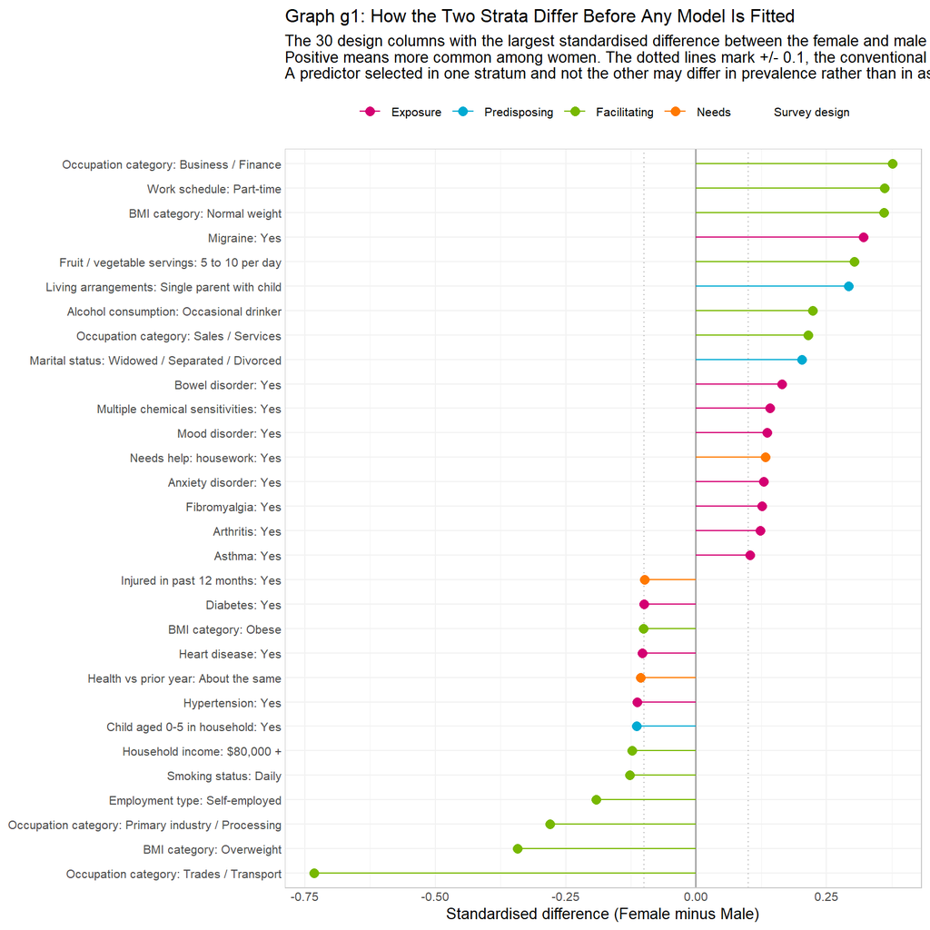

Graph g1 is the diagnostic that model-2 did not need. Every point is a design column that the Section 5.4 candidate set would produce, and its position is how far the two strata differ on it. The dotted lines mark $\pm 0.1$, the conventional threshold below which an imbalance is treated as negligible. Columns that sit far from zero are the ones to hold in mind for the rest of the report: if such a variable is later retained in one stratum and not the other, prevalence is a live explanation and association is not the only one.

Table t2: Stratum feasibility ledger, one row per stratum per predictor set. ‘Dropped as constant’ counts candidate variables that lose all but one level inside the stratum and so cannot be dummy-coded (decision 33); the stratifying variable is removed separately and is not counted here. Both strata carry hundreds of respondents per design column, which is why model-2’s small-subgroup machinery - the n < 500 flag, the minimum-fit threshold, the reversed penalty designation - is absent from model-3.

| Stratum | Predictor set | n | n with >= 1 day | Candidates offered | Dropped as constant | Design columns | Respondents per column | Non-zero per column |
| --- | --- | --- | --- | --- | --- | --- | --- | --- |
| Female | excluding perceived health | 24,273 | 8,608 | 44 | 0 | 85 | 286 | 101 |
| Female | including perceived health | 24,273 | 8,608 | 47 | 0 | 97 | 250 | 89 |
| Male | excluding perceived health | 24,659 | 6,395 | 44 | 0 | 85 | 290 | 75 |
| Male | including perceived health | 24,659 | 6,395 | 47 | 0 | 97 | 254 | 66 |

The last two columns of Table t2 are the reason model-2’s small-subgroup machinery is absent here. Both strata carry hundreds of respondents per design column, so no minimum-size floor is needed, no $n < 500$ flag applies, and the penalty is not doing the work that the data cannot.

```
Output out1: What stratification does to the candidate set
```

```
Section 5.9 asks for 2 models. The PUMF supports 2.
```

```
Section 5.4 describes 4 specifications, all of which are carried (decision 34),
```

```
so model-3 estimates 8 negative binomial models from 4 cross-validated penalised fits.
```

```
Sex leaves the candidate set and becomes the stratification:
```

```
  In model-1 (pooled), sex survived the penalty in these specifications:
 spec_id columns retained
 model_3                1
 model_4                1

  That coefficient is a single multiplicative shift applied to every
  respondent. Stratification replaces it with two complete models, in
  which every coefficient is free to differ. The two are answers to
  different questions and neither supersedes the other.
```

```
Candidate counts offered inside a stratum:
```

```
              Predictor set Section 5.4 count Offered in a stratum Removed
 excluding perceived health                45                   44     sex
 including perceived health                48                   47     sex
```

```
No other candidate is dropped a priori. Table t2 records any variable that
```

```
lost all but one level inside a stratum; at this sample size there should
```

```
be none, and a non-zero count there is worth investigating.
```

**Review point 2**

Agree or disagree with three choices about the candidate set.

1. Decision 33 removes sex and nothing else. Should any other variable be removed a priori inside a stratum — for example, items whose meaning differs by sex — or is dropping only what becomes constant the right rule?
2. Should the standardised differences in Graph g1 carry a formal threshold that triggers an action, or are they a reading aid only? They currently trigger nothing; they exist so that a later asymmetry in selection can be checked against composition.
3. Decision 32 filters the model-1 frame rather than re-deriving complete cases inside each stratum. Filtering keeps Table 5 describing the same respondents as Table 3, at the cost of importing model-1’s missingness rule. Is that the right trade?

## Step 3 — The Stratum Samples

```
Output out2: Sample construction arithmetic
```

```
Source rows (Ellis analytic table):      63,843
```

```
Analytic frame, complete on 48:          48,932  (76.64%)
```

```
  Female stratum:                        24,273  (49.61% of the frame)
```

```
  Male stratum:                          24,659  (50.39% of the frame)
```

```
  Female + Male:                         48,932
```

```
The analytic frame is the model-1 sample, unchanged (decision 32). The two
```

```
strata partition it: every respondent appears in exactly one, and the sum
```

```
of the two is the whole. This is the structural difference from model-2,
```

```
whose seventeen subgroups overlapped heavily and summed to far more than
```

```
the frame. Nothing here needs a comorbidity correction.
```

```
What replaces it is imbalance. Design columns exceeding the conventional
```

```
negligible-difference threshold of 0.1 in absolute standardised difference:
```

```
 design columns compared |SMD| > 0.10 |SMD| > 0.25 largest |SMD|
                      96           28            9         0.733
```

The two strata sum exactly to the analytic frame. That arithmetic is worth stating because it is what model-2 could not state: seventeen condition subgroups overlapped heavily and summed to far more than their frame, which required a comorbidity correction before any coefficient could be read. Nothing of the kind is needed here. What replaces it is the imbalance counted at the foot of out2.

Table t21: Weighted prevalence of each chronic condition within each sex stratum, ordered by the size of the gap. The exposures the study is about are themselves unequally distributed between the strata. A condition retained in the female model and not the male one may be more prevalent, more strongly associated with absence, or simply better powered among women; this table settles the first of those three and the other two remain open.

| Condition | n (F) | Prevalence (F) | n (M) | Prevalence (M) | Difference (pp) | Ratio F / M |
| --- | --- | --- | --- | --- | --- | --- |
| Migraine | 3,672 | 15.34% | 1,490 | 5.65% | +9.69 | 2.71 |
| Arthritis | 3,828 | 12.30% | 2,724 | 8.56% | +3.74 | 1.44 |
| Hypertension | 3,132 | 9.77% | 3,885 | 13.37% | -3.60 | 0.73 |
| Bowel disorder | 1,683 | 5.85% | 689 | 2.56% | +3.29 | 2.28 |
| Mood disorder | 2,137 | 7.67% | 1,159 | 4.43% | +3.24 | 1.73 |
| Anxiety disorder | 1,743 | 6.59% | 927 | 3.73% | +2.86 | 1.77 |
| Asthma | 2,251 | 9.05% | 1,602 | 6.32% | +2.74 | 1.43 |
| Multiple chemical sensitivities | 909 | 3.28% | 370 | 1.19% | +2.09 | 2.76 |
| Diabetes | 940 | 2.92% | 1,389 | 4.84% | -1.92 | 0.60 |
| Heart disease | 438 | 1.32% | 926 | 2.77% | -1.45 | 0.48 |
| Fibromyalgia | 499 | 1.81% | 91 | 0.47% | +1.34 | 3.85 |
| Stomach / intestinal ulcer | 594 | 2.52% | 529 | 2.07% | +0.45 | 1.22 |
| Chronic fatigue syndrome | 285 | 0.98% | 153 | 0.53% | +0.45 | 1.84 |
| Cancer | 269 | 0.98% | 290 | 0.78% | +0.20 | 1.26 |
| Back problems | 4,527 | 17.15% | 4,517 | 16.98% | +0.17 | 1.01 |
| Stroke | 82 | 0.27% | 105 | 0.24% | +0.02 | 1.09 |

Table t21 is the specific form the composition problem takes in this study. The exposures the proposal is about — the chronic conditions — are themselves unequally distributed between the sexes. A condition retained in the female model and not the male one may be more prevalent among women, more strongly associated with absence among women, or simply better powered there. Table t21 settles the first of those three. The second is what Step 8 exists to answer; the third is what Step 9 measures.

**Review point 3**

Agree or disagree that prevalence differences are reported and left standing rather than adjusted for. The alternative would be to reweight one stratum to the other’s composition, which would make the two models describe a common hypothetical population but would no longer describe either observed one. Section 5.9 asks for models of female and male respondents, which is what is estimated; the reweighted alternative is a different question and is not attempted here.

## Step 4 — The Decision Registry

Model 3 inherits nineteen decisions from model-1 and makes ten of its own. It does **not** inherit model-2’s decisions 20 through 30, which are specific to condition subgroups; where model-3 needs the same device — the unstable-term flag, the within-stratum design effect, the two cross-validation variants — it re-makes the decision on its own account, so that changing model-2 cannot silently change model-3.

Table t3: Decision registry for model-3, decisions 31 through 40. Numbering continues from model-2 so that a decision id is unambiguous across the project.

| # | Decision | Alternatives considered | Chosen | Rationale | Reverse by editing |
| --- | --- | --- | --- | --- | --- |
| 31 | The stratification variable | sex as recorded in DHH_SEX; a gender variable; sex crossed with age or cycle | sex (DHH_SEX), two levels | Section 5.9 says ‘female respondents’ and ‘male respondents’. The PUMF carries DHH_SEX, a binary item, in both cycles, and neither cycle carries a gender-identity question. The report therefore says s… | `stratum_var` and `strata_levels` in declare-globals |
| 32 | Stratum base sample | Re-derive complete cases inside each stratum; filter the model-1 complete-case frame | Filter the model-1 frame | Re-deriving would give each stratum its own denominator and its own candidate set, so the female and male models would not be comparable with each other and neither would be comparable with Table 3. F… | `ds1` in tweak-data-0 |
| 33 | Candidate set inside a stratum | Keep sex in the candidate set; remove it; remove it and add its interactions | Remove sex; keep everything else that is informative | Sex is constant inside its own stratum by construction and carries no information there. Nothing else is removed a priori: a variable is dropped only if it loses all but one level inside the stratum, … | `stratum_candidates()` in declare-functions |
| 34 | How many Section 5.4 specifications are carried | One (the Section 5.5 primary); two (one predictor set at both penalties, as model-2 does); all four | All four | Section 5.9 refers selection back to Section 5.4, which describes four specifications on two axes. model-2 carried only the primary predictor set because a condition subgroup of a few hundred responde… | `model_specs` and `candidate_sets` in declare-globals |
| 35 | Penalty rule designated primary | lambda.1se as Section 5.5 designates; lambda.min as model-2 designates for small subgroups | lambda.1se, without perceived health (Model 1) | model-2 reversed this ordering with decision 25, but the argument there was scale: a parsimonious penalty applied to a subgroup of a few hundred respondents frequently returns nothing at all. In model… | `primary_spec` in declare-globals |
| 36 | Design effect basis | Reuse model-1’s full-sample Kish design effect; compute one within each stratum | Within each stratum | A design effect describes the weight distribution of the sample whose intervals it widens. Weights inside a sex stratum are not distributed as they are in the pooled sample, and Output out5 shows the … | `build_stratum()` in declare-functions |
| 37 | Weight rescaling | Carry model-1’s weight into the stratum unchanged; rescale to mean 1 within each stratum | Rescale within each stratum | glm.nb treats prior weights as frequencies when estimating dispersion, so a stratum whose carried-forward weights average far from 1 would return a theta on a different scale from the other. Rescaling… | `build_stratum()` in declare-functions |
| 38 | Section 5.10 resampling method | 5-fold cross-validation; leave-one-out; a single train / test split | 5-fold, in both variants of inherited decision 16 | Section 5.10 names five folds and, unlike Section 5.8, does not offer leave-one-out - which is consistent, because both strata are large. The term set is scored twice over: once held fixed at what the… | `perf_folds` in declare-globals |
| 39 | Basis for the female-male comparison | Compare the two selected models term by term; compare only terms selected in both; refit both strata on the union of the two selected sets | Refit on the union set | Section 5.9 asks the stratified models to ‘highlight potential differences in the determinants of absenteeism between men and women’. Comparing the two SELECTED models cannot do that cleanly: a term m… | `union_terms` and `nb_union` in the t65 block |
| 40 | Rare levels and unstable terms | Collapse rare levels; drop variables that have a rare level; retain and flag | Retain and flag at SE > 2 on the log scale | The same device model-2 adopted with decision 27, re-made here rather than inherited. It matters much less at stratum scale than at subgroup scale - both strata carry more than twenty thousand respond… | `unstable_se` in declare-globals |

Table t31: The nineteen decisions model-3 inherits from model-1 unchanged. Alternatives, rationale and reversal instructions are in model-1 Table t3 and are deliberately not restated here, because two copies of a decision drift apart. Model-2’s decisions 20 through 30 are NOT inherited: they concern condition subgroups. Decisions 35, 36, 38 and 40 re-make the four of them that describe devices model-3 also needs.

| # | Decision | Chosen in model-1 |
| --- | --- | --- |
| 1 | Outcome variable | days_absent_total |
| 2 | COPD indicator | Exclude |
| 3 | Family doctor indicator | Exclude |
| 4 | Age resolution | age_group_3 |
| 5 | Missing data handling | Complete case |
| 6 | Perceived health definition | The 3 self-perceived measures |
| 7 | Dummy coding scheme | Reference contrasts |
| 8 | Cycle indicator | Unpenalised (penalty.factor = 0) |
| 9 | Carry-forward rule to stage 2 | Any surviving column promotes the whole factor |
| 10 | Variance estimation | Wald standard errors (bootstrap weights absent from the PUMF) |
| 11 | Penalty selection | 5-fold CV, seed 42 |
| 12 | Weights in cross-validation | Weighted likelihood |
| 13 | Child-presence flag dhhgl12 | Descriptives and bivariate models only |
| 14 | Homeownership | Include DHH_OWN directly as home_ownership |
| 15 | Interval reporting | Wald, sandwich and Kish-inflated, side by side |
| 16 | Basis for the held-out cross-validation | Both fixed term set and selection re-run |
| 17 | C-statistic for a count outcome | Harrell’s C on predicted mean vs observed count |
| 18 | Information criteria under weighting | Report with a pseudo-likelihood caveat |
| 19 | Scale of the error metrics | Weighted |

**The same decision cannot be reversed here either**

Inherited decision 10 records that bootstrap variance estimation is impossible with these data. Section 5.9 asks for 500 bootstrap replicate weights in the same words Sections 5.3, 5.5 and 5.7 use, and the answer is the same: CCHS bootstrap replicate weights begin with the 2015 cycle, neither the 2010 nor the 2014 PUMF carries them, and strata and PSU identifiers are suppressed.

Model 3 responds as its predecessors do — a Wald interval beside a Huber–White sandwich interval and a Kish-inflated interval — with the design effect computed *within each stratum* (decision 36), because the weight distribution inside a sex stratum is not the weight distribution of the pooled sample. Output out5 shows how far the two differ.

**Review point 4**

Read decisions 31 through 40. Three are consequential and the rest are bookkeeping:

1. **Decision 34** carries all four Section 5.4 specifications rather than the two model-2 could afford. This is what makes Table 5 readable row-for-row against Table 3.
2. **Decision 35** keeps `lambda.1se` primary, declining model-2’s reversal. The argument is scale, and Table t5 supplies the evidence for or against it.
3. **Decision 39** builds the female–male comparison on a union model rather than on the two selected models. This is the report’s central methodological choice and Step 8 is where its consequences appear.

## Step 5 — The Four Specifications

Section 5.9 says selection should follow the Section 5.4 procedure. Section 5.4 describes four specifications, arranged on two axes: a perceived-health toggle and a penalty rule. Model 2 carried only two of them, because a condition subgroup of a few hundred respondents cannot support a four-way comparison. A sex stratum is roughly half the Section 5.5 analytic sample, so that constraint does not apply and model-3 answers the reference literally.

Table t4: The four Section 5.4 specifications, carried in full into each stratum (decision 34). The predictor set defines the cross-validated fit; the penalty selects a model from it, so two fits per stratum yield four models. Model 1 is primary, following Section 5.5 and unlike model-2, which reversed the designation for small subgroups only (decision 35). Every row has a direct counterpart in model-1’s Table 3, which is what makes Table 5 readable against Table 3.

| Specification | Role | Penalty | Perceived health | Candidates offered | Shares a fit with | Section 5.5 counterpart |
| --- | --- | --- | --- | --- | --- | --- |
| Model 1 | Primary | lambda.1se | excluded | 44 (sex removed) | Models 1 and 3 | Table 3 Model 1 |
| Model 2 | Secondary | lambda.1se | included | 47 (sex removed) | Models 2 and 4 | Table 3 Model 2 |
| Model 3 | Sensitivity | lambda.min | excluded | 44 (sex removed) | Models 1 and 3 | Table 3 Model 3 |
| Model 4 | Sensitivity | lambda.min | included | 47 (sex removed) | Models 2 and 4 | Table 3 Model 4 |

The arithmetic in the “shares a fit with” column matters for reading the rest of the report. The predictor set defines the cross-validated fit; the penalty rule selects a model from it. Two predictor sets in two strata therefore cost four penalised fits, not eight, and Models 1 and 3 differ only in where on the same path they are read.

**Review point 5**

Agree or disagree that all four specifications should be carried into the deliverable table. The alternative is to report only Model 1 and relegate the rest to an appendix, which would make Table 5 far shorter and would match the way Section 5.9 is worded — it asks for “a model,” singular, per sex. The argument for carrying four is that it makes the sex-stratified table comparable with Table 3 specification by specification, and that the cost is a wider table rather than more computation.

## Step 6 — Stage One, Per-Stratum Penalised Poisson

Four weighted L1-penalised Poisson fits: two strata by two predictor sets, each with its own five-fold cross-validated penalty path.

**Fit and persist one cross-validated penalised Poisson model per stratum and predictor set**

```r
fit_keys <- tidyr::expand_grid(stratum = strata_levels, fit_id = fit_ids) %>%
  mutate(key = paste0(stratum, "__", fit_id))

stratum_fits <- purrr::set_names(
  purrr::map2(fit_keys$stratum, fit_keys$fit_id, fit_stratum_spec),
  fit_keys$key
)

for (this_key in names(stratum_fits)) {
  sf <- stratum_fits[[this_key]]
  if (!is.null(sf$lasso)) {
    saveRDS(sf$lasso$cv, paste0(fits_folder, "cv_", this_key, ".rds"))
    saveRDS(sf$design$map, paste0(fits_folder, "map_", this_key, ".rds"))
  }
}

fitted_ok <- names(stratum_fits)[purrr::map_lgl(stratum_fits, ~ !is.null(.x$lasso))]
stopifnot(length(fitted_ok) == nrow(fit_keys))

fit_panel_label <- function(key) {
  parts <- strsplit(key, "__", fixed = TRUE)[[1]]
  paste0(parts[1], " - perceived health ",
         ifelse(parts[2] == "include", "included", "excluded"))
}
panel_levels <- purrr::map_chr(fit_keys$key, fit_panel_label)

cv_curve_data <- purrr::map_dfr(fitted_ok, function(this_key) {
  cv <- stratum_fits[[this_key]]$lasso$cv
  tibble::tibble(
    key = this_key,
    lambda = cv$lambda,
    cv_mean = cv$cvm,
    cv_low = cv$cvlo,
    cv_high = cv$cvup,
    n_nonzero = cv$nzero
  )
}) %>%
  mutate(panel = factor(purrr::map_chr(key, fit_panel_label), levels = panel_levels))

lambda_marks <- purrr::map_dfr(fitted_ok, function(this_key) {
  cv <- stratum_fits[[this_key]]$lasso$cv
  tibble::tibble(
    key = this_key,
    lambda_rule = c("lambda.1se", "lambda.min"),
    lambda = c(cv$lambda.1se, cv$lambda.min)
  )
}) %>%
  mutate(panel = factor(purrr::map_chr(key, fit_panel_label), levels = panel_levels))

path_data <- purrr::map_dfr(fitted_ok, function(this_key) {
  sf <- stratum_fits[[this_key]]
  as.matrix(sf$lasso$path$beta) %>%
    as.data.frame() %>%
    tibble::rownames_to_column("column") %>%
    tidyr::pivot_longer(-column, names_to = "step", values_to = "estimate") %>%
    mutate(
      lambda = sf$lasso$path$lambda[as.integer(sub("^s", "", step)) + 1],
      key = this_key
    ) %>%
    left_join(sf$design$map, by = "column")
}) %>%
  mutate(
    domain = variable_domains[variable],
    panel = factor(purrr::map_chr(key, fit_panel_label), levels = panel_levels)
  )
```

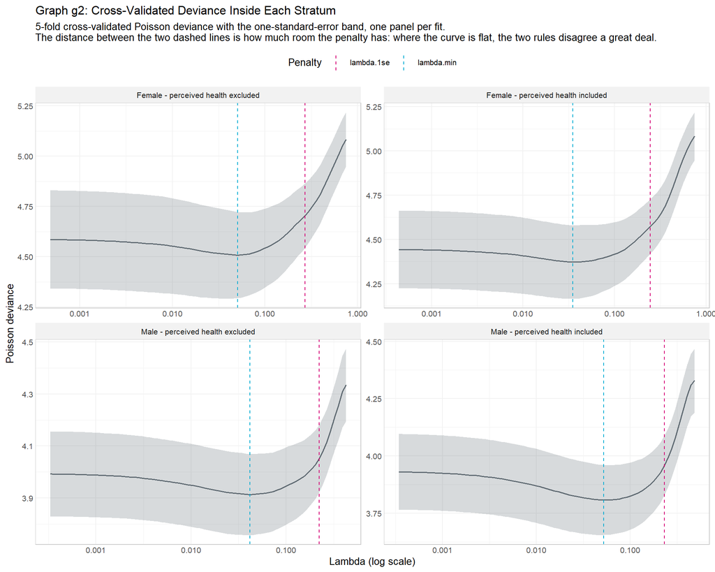

The quantity to read in Graph g2 is the distance between the two dashed lines relative to the depth of the minimum. That distance is how much room the penalty has: where the curve is flat over a wide range, cross-validation cannot distinguish penalties there, and the two rules will disagree a great deal about how many variables to keep. Comparing the female and male panels of the same predictor set is the first indication of whether the two strata are equally decisive.

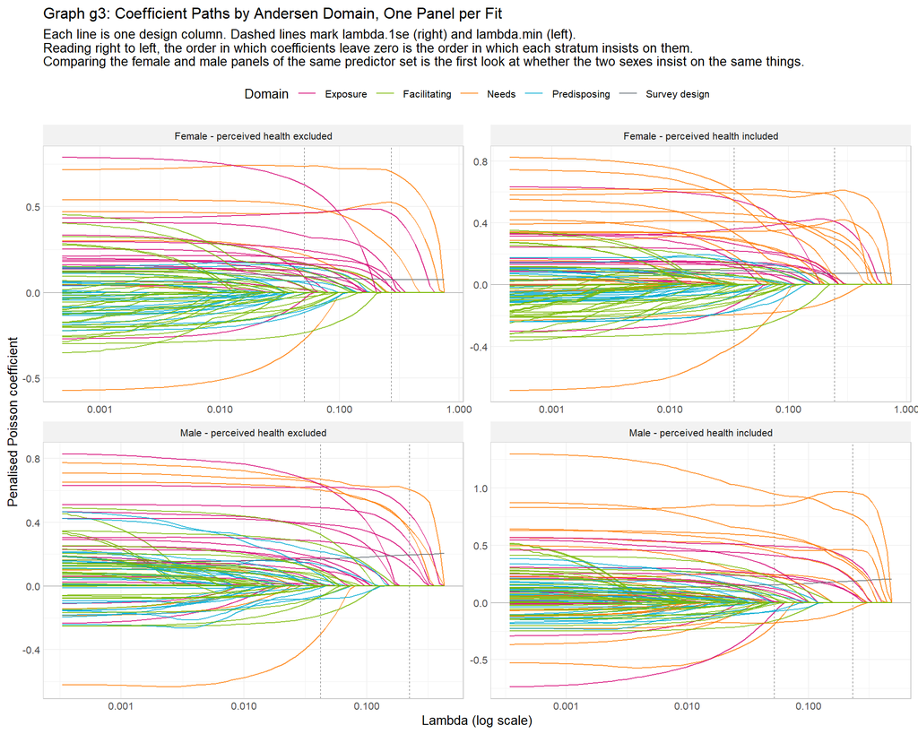

Reading each panel right to left, the order in which coefficients leave zero is the order in which that stratum insists on them. Comparing the female and male panels of the same predictor set is the first visual answer to Section 5.9 — but only the first, and a weak one: the paths show what the penalty did, not what the associations are, and Step 8 is where the two are separated.

**Review point 6**

Agree or disagree with the fitting choices, which are inherited unchanged from model-1: five folds, seed 42, survey weights passed to `cv.glmnet`, cycle exempt from the penalty. One consideration is new. Each stratum’s folds are cut inside that stratum, so the female and male cross-validations are independent and use different respondents. An alternative would cut folds once in the pooled frame and inherit them, which would make the two penalty paths share a fold structure. Neither is obviously right; the current choice keeps each stratum a self-contained analysis.

## Step 7 — Selection Results

Table t5: What each stratum retained under each of the four Section 5.4 specifications. The cycle indicator is exempt from the penalty (inherited decision 8), so a count of 1 variable would mean nothing but cycle survived. Reading the two rows of a specification against each other is the first quantitative answer to Section 5.9: if the female and male models retain different numbers of variables, the determinants of absence are not equally identifiable in the two populations.

| Specification | Stratum | n | n with >= 1 day | Columns offered | Columns retained | Variables retained | Of which exposure |
| --- | --- | --- | --- | --- | --- | --- | --- |
| Model 1 | Female | 24,273 | 8,608 | 85 | 9 | 9 | 5 |
| Model 1 | Male | 24,659 | 6,395 | 85 | 8 | 8 | 4 |
| Model 2 | Female | 24,273 | 8,608 | 97 | 15 | 12 | 5 |
| Model 2 | Male | 24,659 | 6,395 | 97 | 13 | 10 | 4 |
| Model 3 | Female | 24,273 | 8,608 | 85 | 41 | 37 | 15 |
| Model 3 | Male | 24,659 | 6,395 | 85 | 37 | 29 | 13 |
| Model 4 | Female | 24,273 | 8,608 | 97 | 52 | 38 | 12 |
| Model 4 | Male | 24,659 | 6,395 | 97 | 32 | 24 | 10 |

Two comparisons carry Table t5. Reading **across** a specification, the gap between the two strata is the first quantitative answer to Section 5.9: if the female and male models retain different numbers of variables, the determinants of absence are not equally identifiable in the two populations. Reading **down** a stratum, the gap between the `1SE` rows and the `min` rows is the evidence for decision 35 — whether the parsimonious rule still has something to say at stratum scale, which is exactly the question on which model-2 answered differently.

Table t51: Which variables each stratum retained, and under which of the four specifications. A cell reading ‘1, 3’ means the variable survived in Models 1 and 3 of that stratum; an empty cell means it was offered and eliminated in all four. The ‘Agreement’ column is the Section 5.9 summary: ‘female only’ and ‘male only’ are the candidate sex-specific predictors, and they are candidates rather than findings until Table t65 shows what the other stratum’s estimate would have been.

| Domain | Variable | Female (models) | Male (models) | Agreement |
| --- | --- | --- | --- | --- |
| Exposure | Anxiety disorder | 3, 4 | 3 | both |
| Exposure | Arthritis | 3 | 1, 2, 3, 4 | both |
| Exposure | Back problems | 1, 2, 3, 4 | 1, 2, 3, 4 | both |
| Exposure | Bowel disorder | 1, 2, 3, 4 | 3, 4 | both |
| Exposure | Cancer | 3, 4 | 3, 4 | both |
| Exposure | Chronic fatigue syndrome | 1, 2, 3, 4 | 4 | both |
| Exposure | Diabetes | 3, 4 | 3 | both |
| Exposure | Fibromyalgia | 3, 4 | 3 | both |
| Exposure | Heart disease | 3 | 3, 4 | both |
| Exposure | Hypertension | 3 | 3, 4 | both |
| Exposure | Migraine | 1, 2, 3, 4 | 1, 2, 3, 4 | both |
| Exposure | Mood disorder | 1, 2, 3, 4 | 1, 2, 3, 4 | both |
| Exposure | Stomach / intestinal ulcer | 3, 4 | 3 | both |
| Exposure | Asthma | 3, 4 |  | female only |
| Exposure | Stroke | 3, 4 |  | female only |
| Exposure | Multiple chemical sensitivities |  | 3, 4 | male only |
| Predisposing | Child aged 6-11 in household | 3, 4 | 3, 4 | both |
| Predisposing | Home ownership | 3, 4 | 3 | both |
| Predisposing | Living arrangements | 3, 4 | 3, 4 | both |
| Predisposing | Marital status | 3, 4 | 3, 4 | both |
| Predisposing | Age group | 3, 4 |  | female only |
| Predisposing | Household size | 4 |  | female only |
| Predisposing | Immigration status | 3, 4 |  | female only |
| Predisposing | Visible minority | 4 |  | female only |
| Predisposing | Child aged 0-5 in household |  |  | neither |
| Predisposing | Education |  |  | neither |
| Facilitating | BMI category | 3, 4 | 3 | both |
| Facilitating | Employment type | 3, 4 | 3, 4 | both |
| Facilitating | Fruit / vegetable servings | 3, 4 | 3 | both |
| Facilitating | Occupation category | 3, 4 | 3, 4 | both |
| Facilitating | Province | 3, 4 | 3, 4 | both |
| Facilitating | Smoking status | 3 | 3 | both |
| Facilitating | Work stress | 3, 4 | 3, 4 | both |
| Facilitating | Household income | 3, 4 |  | female only |
| Facilitating | Physical activity | 3, 4 |  | female only |
| Facilitating | Work schedule | 3, 4 |  | female only |
| Facilitating | Alcohol consumption |  |  | neither |
| Needs | Health vs prior year | 2, 4 | 2, 4 | both |
| Needs | Injured in past 12 months | 1, 2, 3, 4 | 1, 2, 3, 4 | both |
| Needs | Needs help: errands | 1, 2, 3, 4 | 1, 2, 3, 4 | both |
| Needs | Needs help: housework | 1, 2, 3, 4 | 1, 2, 3, 4 | both |
| Needs | Self-perceived general health | 2, 4 | 2, 4 | both |
| Needs | Needs help: meals | 2, 3, 4 |  | female only |
| Needs | Needs help: personal care | 3, 4 |  | female only |
| Needs | Self-perceived mental health | 4 |  | female only |
| Needs | Needs help: finances |  | 3, 4 | male only |
| Needs | Needs help: moving indoors |  |  | neither |
| Survey design | CCHS cycle | 1, 2, 3, 4 | 1, 2, 3, 4 | both |

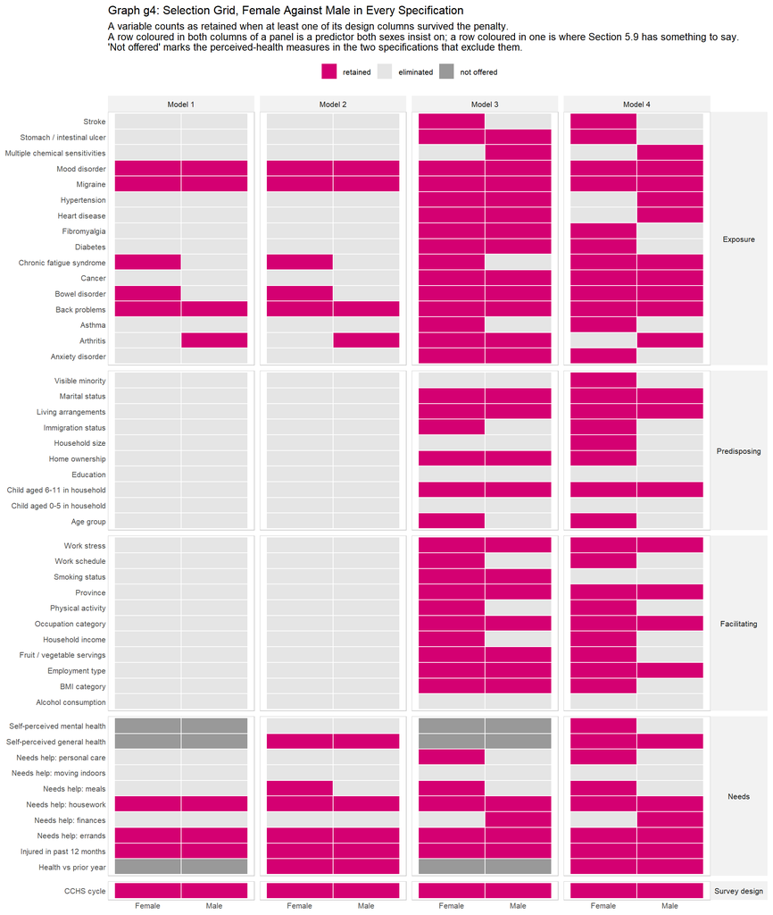

Graph g4 is the visual form of the selection result, and it is read across the two columns of a panel rather than down. A row coloured in both columns is a predictor both sexes insist on. A row coloured in one is where Section 5.9 has something to say — **potentially**. The word is doing real work: an asymmetry in this grid is a fact about the *procedure*, and it becomes a fact about the *data* only if the other stratum’s estimate for that term is also small, which the grid cannot show. Table t65 is where that check happens, and Step 8 explains why it needs a different model to do it.

**Review point 7**

Two questions to settle before the estimates in Step 8 may be read.

1. Should “retained” continue to mean “at least one design column survived”? Inherited decision 9 records the alternative. It matters here because a factor retained in one stratum on the strength of a single level will appear in Graph g4 as a whole-variable asymmetry.
2. Is the asymmetry in Graph g4 worth reporting in its own right, or only as a route to Table t65? Model 2 reported its selection grid as a central artifact because cross-condition recurrence was itself a finding. Here the analogous claim would be weaker, since two columns cannot establish a pattern the way seventeen can.

## Step 8 — Stage Two, Negative Binomial Estimation

Each retained set is re-estimated without penalty under a negative binomial likelihood, inside its own stratum. This step answers Section 5.9 and produces deliverable **Table 5**. Before the estimates, the instruments used to bracket their uncertainty.

**Fit and persist the eight sex-stratified negative binomial models**

```r
nb_keys <- tidyr::expand_grid(
  stratum = strata_levels,
  spec_id = model_specs$spec_id
) %>%
  mutate(key = paste0(stratum, "__", spec_id))

spec_terms <- purrr::set_names(
  purrr::map2(nb_keys$stratum, nb_keys$spec_id, function(this_stratum, this_spec) {
    this_fit_id <- model_specs$fit_id[model_specs$spec_id == this_spec]
    sf <- stratum_fits[[paste0(this_stratum, "__", this_fit_id)]]
    kept <- selection_long %>%
      filter(stratum == this_stratum, spec_id == this_spec) %>%
      retained_variables()
    union(sf$forced, setdiff(kept, sf$forced))
  }),
  nb_keys$key
)

nb_fits <- purrr::imap(spec_terms, function(term_vars, this_key) {
  this_stratum <- sub("__.*$", "", this_key)
  fit_nb(strata[[this_stratum]], term_vars, outcome_var)
})

nb_nulls <- purrr::map(
  stats::setNames(strata_levels, strata_levels),
  ~ fit_nb(strata[[.x]], character(0), outcome_var)
)

for (this_key in names(nb_fits)) {
  if (!is.null(nb_fits[[this_key]])) {
    saveRDS(nb_fits[[this_key]], paste0(fits_folder, "nb_", this_key, ".rds"))
  }
}
saveRDS(nb_nulls, paste0(fits_folder, "nb_nulls.rds"))

stratum_deff <- stats::setNames(stratum_inventory$kish_deff, stratum_inventory$stratum)

nb_coefficients <- purrr::imap_dfr(nb_fits, function(fit, this_key) {
  if (is.null(fit)) return(tibble::tibble())
  this_stratum <- sub("__.*$", "", this_key)
  this_spec <- sub("^.*__", "", this_key)
  this_fit_id <- model_specs$fit_id[model_specs$spec_id == this_spec]
  column_map <- stratum_fits[[paste0(this_stratum, "__", this_fit_id)]]$design$map
  tidy_nb(fit, column_map, deff = stratum_deff[[this_stratum]]) %>%
    mutate(stratum = this_stratum, spec_id = this_spec)
}) %>%
  left_join(model_specs %>% select(spec_id, model_label, role), by = "spec_id") %>%
  mutate(
    domain = variable_domains[variable],
    variable_label = variable_labels[variable],
    term = paste0(variable_label, ifelse(level == "", "", paste0(": ", level)))
  )

readr::write_csv(nb_coefficients, paste0(local_data, "nb-coefficients.csv"))
```

```
Output out5: Variance-estimation instruments for Section 5.9
```

```
Section 5.9 asks for 500 bootstrap replicate weights, the same instrument
```

```
Sections 5.3, 5.5 and 5.7 ask for. They do not exist in the 2010 or 2014
```

```
PUMF (inherited decision 10), and strata and PSU identifiers are
```

```
suppressed, so no fully design-based variance estimator can be built for
```

```
either stratum. What follows are two LOWER bounds on how far the
```

```
model-based intervals understate uncertainty. Neither sees clustering.
```

```
Kish design effect, computed WITHIN each stratum (decision 36):
```

```
 Stratum      n Kish deff Effective n SE multiplier
  Female 24,273     3.742       6,487         1.934
    Male 24,659     3.518       7,010         1.876
```

```
Huber-White sandwich SE multiplier, over every term in every fitted model:
```

[output not shown]

```
Both instruments are close to their model-1 values, which is what a
```

```
stratification of a large sample should produce: halving a sample does not
```

```
change how unequal its weights are. Table t62 reports all three interval
```

```
variants side by side and marks terms whose standard error exceeds 2
on the log scale (decision 40).
```

The design effect is computed within each stratum rather than inherited from the pooled sample, because a design effect describes the weight distribution of the sample whose intervals it widens. Both instruments should land close to their model-1 values, and that is the expected result rather than a reassuring one: halving a sample does not change how unequal its weights are.

Table t6 (deliverable Table 5): Adjusted prevalence rate ratios with 95% Wald intervals for every term retained inside each sex stratum, under all four Section 5.4 specifications. An asterisk marks Wald p < 0.05; an exclamation mark flags a term whose standard error exceeds 2 on the log scale (decision 40). A blank cell means the term was not retained by that specification. These are NOT bootstrap intervals (inherited decision 10), and they ignore the selection step that produced the term list. Table t62 carries the log-scale coefficients, standard errors, exact p-values and two wider interval variants; Table t65 carries the female-male comparison, which this table deliberately does not support.

| Stratum | n | Weighted N | Domain | Term | Model 1 | Model 2 | Model 3 | Model 4 |
| --- | --- | --- | --- | --- | --- | --- | --- | --- |
| Female | 24,273 | 6,371,630 | Exposure | Anxiety disorder: Yes |  |  | 1.30 (1.16-1.47)* | 1.17 (1.04-1.32)* |
| Female | 24,273 | 6,371,630 | Exposure | Arthritis: Yes |  |  | 1.21 (1.11-1.33)* |  |
| Female | 24,273 | 6,371,630 | Exposure | Asthma: Yes |  |  | 1.27 (1.15-1.40)* | 1.27 (1.15-1.40)* |
| Female | 24,273 | 6,371,630 | Exposure | Back problems: Yes | 1.44 (1.33-1.55)* | 1.31 (1.22-1.42)* | 1.34 (1.24-1.45)* | 1.25 (1.16-1.35)* |
| Female | 24,273 | 6,371,630 | Exposure | Bowel disorder: Yes | 1.46 (1.29-1.65)* | 1.30 (1.15-1.47)* | 1.37 (1.21-1.54)* | 1.22 (1.09-1.38)* |
| Female | 24,273 | 6,371,630 | Exposure | Cancer: Yes |  |  | 2.69 (2.04-3.53)* | 2.12 (1.62-2.77)* |
| Female | 24,273 | 6,371,630 | Exposure | Chronic fatigue syndrome: Yes | 1.92 (1.44-2.54)* | 1.39 (1.05-1.83)* | 1.71 (1.29-2.27)* | 1.63 (1.24-2.14)* |
| Female | 24,273 | 6,371,630 | Exposure | Diabetes: Yes |  |  | 1.24 (1.04-1.47)* | 1.16 (0.98-1.37) |
| Female | 24,273 | 6,371,630 | Exposure | Fibromyalgia: Yes |  |  | 0.85 (0.69-1.06) | 0.81 (0.66-1.01) |
| Female | 24,273 | 6,371,630 | Exposure | Heart disease: Yes |  |  | 1.80 (1.42-2.29)* |  |
| Female | 24,273 | 6,371,630 | Exposure | Hypertension: Yes |  |  | 1.05 (0.95-1.17) |  |
| Female | 24,273 | 6,371,630 | Exposure | Migraine: Yes | 1.41 (1.30-1.52)* | 1.33 (1.23-1.44)* | 1.26 (1.16-1.36)* | 1.23 (1.14-1.33)* |
| Female | 24,273 | 6,371,630 | Exposure | Mood disorder: Yes | 1.95 (1.75-2.17)* | 1.68 (1.51-1.86)* | 1.62 (1.45-1.82)* | 1.38 (1.23-1.55)* |
| Female | 24,273 | 6,371,630 | Exposure | Stomach / intestinal ulcer: Yes |  |  | 1.76 (1.48-2.10)* | 1.33 (1.12-1.59)* |
| Female | 24,273 | 6,371,630 | Exposure | Stroke: Yes |  |  | 2.23 (1.32-3.77)* | 1.57 (0.94-2.63) |
| Female | 24,273 | 6,371,630 | Predisposing | Age group: 25-54 |  |  | 1.08 (0.96-1.21) | 1.10 (0.98-1.24) |
| Female | 24,273 | 6,371,630 | Predisposing | Age group: 55-75 |  |  | 0.80 (0.70-0.93)* | 0.85 (0.74-0.98)* |
| Female | 24,273 | 6,371,630 | Predisposing | Child aged 6-11 in household: Yes |  |  | 0.96 (0.88-1.05) | 0.95 (0.87-1.04) |
| Female | 24,273 | 6,371,630 | Predisposing | Home ownership: Renter |  |  | 1.09 (1.01-1.18)* | 1.12 (1.04-1.21)* |
| Female | 24,273 | 6,371,630 | Predisposing | Household size: 2 persons |  |  |  | 1.22 (0.98-1.52) |
| Female | 24,273 | 6,371,630 | Predisposing | Household size: 3 persons |  |  |  | 0.99 (0.83-1.18) |
| Female | 24,273 | 6,371,630 | Predisposing | Household size: 4 persons |  |  |  | 0.94 (0.79-1.13) |
| Female | 24,273 | 6,371,630 | Predisposing | Household size: 5 or more persons |  |  |  | 0.89 (0.74-1.07) |
| Female | 24,273 | 6,371,630 | Predisposing | Immigration status: Long-term immigrant (10+ yrs in Canada) |  |  | 0.80 (0.74-0.87)* | 0.81 (0.74-0.89)* |
| Female | 24,273 | 6,371,630 | Predisposing | Immigration status: Recent immigrant (0-9 yrs in Canada) |  |  | 0.72 (0.62-0.82)* | 0.66 (0.56-0.76)* |
| Female | 24,273 | 6,371,630 | Predisposing | Living arrangements: Child in parent / sibling household |  |  | 1.12 (0.91-1.38) | 0.96 (0.75-1.23) |
| Female | 24,273 | 6,371,630 | Predisposing | Living arrangements: Child in two-parent / sibling household |  |  | 0.86 (0.73-1.02) | 0.85 (0.70-1.04) |
| Female | 24,273 | 6,371,630 | Predisposing | Living arrangements: Couple with children |  |  | 0.99 (0.82-1.20) | 0.97 (0.84-1.12) |
| Female | 24,273 | 6,371,630 | Predisposing | Living arrangements: Couple, no children |  |  | 1.00 (0.83-1.21) | 0.75 (0.61-0.92)* |
| Female | 24,273 | 6,371,630 | Predisposing | Living arrangements: Other arrangement |  |  | 1.00 (0.84-1.18) |  |

[output cut: 124 more lines]

Table t62 (deliverable Table 5, full ledger): Everything Section 5.9 asks to be reported - unweighted n, weighted N, log-scale coefficient, standard error, prevalence rate ratio, 95% interval and Wald p-value - for every term in every sex-stratified model. The sandwich and Kish columns bracket the understatement caused by the absent bootstrap weights (inherited decisions 10 and 15); both are lower bounds. All intervals remain conditional on a selection step that used the same stratum.

| Stratum | n | Weighted N | Specification | Domain | Term | Beta (log) | SE | SE robust | PR | 95% CI (Wald) | 95% CI (sandwich) | 95% CI (Kish) | p (Wald) | p (robust) | Flag |
| --- | --- | --- | --- | --- | --- | --- | --- | --- | --- | --- | --- | --- | --- | --- | --- |
| Female | 24,273 | 6,371,630 | Model 1 | Exposure | Back problems: Yes | 0.3634 | 0.0397 | 0.0815 | 1.438 | 1.331-1.555 | 1.226-1.687 | 1.237-1.672 | <0.0001 | <0.0001 |  |
| Female | 24,273 | 6,371,630 | Model 1 | Exposure | Bowel disorder: Yes | 0.3798 | 0.0621 | 0.0894 | 1.462 | 1.294-1.651 | 1.227-1.742 | 1.155-1.850 | <0.0001 | <0.0001 |  |
| Female | 24,273 | 6,371,630 | Model 1 | Exposure | Chronic fatigue syndrome: Yes | 0.6500 | 0.1449 | 0.1855 | 1.916 | 1.442-2.545 | 1.332-2.755 | 1.106-3.319 | <0.0001 | 0.0005 |  |
| Female | 24,273 | 6,371,630 | Model 1 | Exposure | Migraine: Yes | 0.3410 | 0.0410 | 0.0974 | 1.406 | 1.298-1.524 | 1.162-1.702 | 1.204-1.643 | <0.0001 | 0.0005 |  |
| Female | 24,273 | 6,371,630 | Model 1 | Exposure | Mood disorder: Yes | 0.6664 | 0.0549 | 0.0782 | 1.947 | 1.749-2.168 | 1.670-2.270 | 1.581-2.397 | <0.0001 | <0.0001 |  |
| Female | 24,273 | 6,371,630 | Model 1 | Needs | Injured in past 12 months: Yes | 0.6125 | 0.0417 | 0.0710 | 1.845 | 1.700-2.002 | 1.605-2.121 | 1.575-2.161 | <0.0001 | <0.0001 |  |
| Female | 24,273 | 6,371,630 | Model 1 | Needs | Needs help: errands: Yes | 0.9221 | 0.1196 | 0.1836 | 2.515 | 1.989-3.179 | 1.755-3.604 | 1.598-3.957 | <0.0001 | <0.0001 |  |
| Female | 24,273 | 6,371,630 | Model 1 | Needs | Needs help: housework: Yes | 0.5841 | 0.0890 | 0.1372 | 1.793 | 1.506-2.135 | 1.371-2.347 | 1.280-2.513 | <0.0001 | <0.0001 |  |
| Female | 24,273 | 6,371,630 | Model 1 | Survey design | CCHS cycle: 2013-2014 | 0.1230 | 0.0298 | 0.0835 | 1.131 | 1.067-1.199 | 0.960-1.332 | 1.010-1.266 | <0.0001 | 0.1406 |  |
| Female | 24,273 | 6,371,630 | Model 2 | Exposure | Back problems: Yes | 0.2733 | 0.0391 | 0.0844 | 1.314 | 1.217-1.419 | 1.114-1.551 | 1.133-1.525 | <0.0001 | 0.0012 |  |
| Female | 24,273 | 6,371,630 | Model 2 | Exposure | Bowel disorder: Yes | 0.2628 | 0.0609 | 0.0861 | 1.301 | 1.154-1.465 | 1.099-1.540 | 1.032-1.638 | <0.0001 | 0.0023 |  |
| Female | 24,273 | 6,371,630 | Model 2 | Exposure | Chronic fatigue syndrome: Yes | 0.3293 | 0.1417 | 0.1845 | 1.390 | 1.053-1.835 | 0.968-1.996 | 0.812-2.379 | 0.0201 | 0.0743 |  |
| Female | 24,273 | 6,371,630 | Model 2 | Exposure | Migraine: Yes | 0.2840 | 0.0402 | 0.0945 | 1.328 | 1.228-1.437 | 1.104-1.599 | 1.141-1.547 | <0.0001 | 0.0027 |  |
| Female | 24,273 | 6,371,630 | Model 2 | Exposure | Mood disorder: Yes | 0.5171 | 0.0541 | 0.0800 | 1.677 | 1.508-1.865 | 1.434-1.962 | 1.366-2.059 | <0.0001 | <0.0001 |  |
| Female | 24,273 | 6,371,630 | Model 2 | Needs | Health vs prior year: About the same | -0.2097 | 0.0514 | 0.1345 | 0.811 | 0.733-0.897 | 0.623-1.055 | 0.667-0.985 | <0.0001 | 0.1189 |  |
| Female | 24,273 | 6,371,630 | Model 2 | Needs | Health vs prior year: Much worse | 0.6829 | 0.1676 | 0.2018 | 1.980 | 1.425-2.750 | 1.333-2.940 | 1.048-3.738 | <0.0001 | 0.0007 |  |
| Female | 24,273 | 6,371,630 | Model 2 | Needs | Health vs prior year: Somewhat better | -0.0980 | 0.0627 | 0.1357 | 0.907 | 0.802-1.025 | 0.695-1.183 | 0.715-1.150 | 0.1183 | 0.4702 |  |
| Female | 24,273 | 6,371,630 | Model 2 | Needs | Health vs prior year: Somewhat worse | 0.4157 | 0.0670 | 0.1495 | 1.516 | 1.329-1.728 | 1.131-2.032 | 1.176-1.954 | <0.0001 | 0.0054 |  |
| Female | 24,273 | 6,371,630 | Model 2 | Needs | Injured in past 12 months: Yes | 0.5998 | 0.0408 | 0.0701 | 1.822 | 1.682-1.973 | 1.588-2.090 | 1.561-2.126 | <0.0001 | <0.0001 |  |
| Female | 24,273 | 6,371,630 | Model 2 | Needs | Needs help: errands: Yes | 0.6527 | 0.1299 | 0.1483 | 1.921 | 1.489-2.478 | 1.436-2.569 | 1.174-3.143 | <0.0001 | <0.0001 |  |
| Female | 24,273 | 6,371,630 | Model 2 | Needs | Needs help: housework: Yes | 0.3041 | 0.0897 | 0.1374 | 1.355 | 1.137-1.616 | 1.036-1.774 | 0.965-1.905 | 0.0007 | 0.0268 |  |
| Female | 24,273 | 6,371,630 | Model 2 | Needs | Needs help: meals: Yes | 0.2996 | 0.1665 | 0.2403 | 1.349 | 0.974-1.870 | 0.842-2.161 | 0.718-2.536 | 0.0719 | 0.2125 |  |
| Female | 24,273 | 6,371,630 | Model 2 | Needs | Self-perceived general health: Fair | 0.9113 | 0.0714 | 0.1483 | 2.487 | 2.163-2.861 | 1.860-3.327 | 1.898-3.261 | <0.0001 | <0.0001 |  |
| Female | 24,273 | 6,371,630 | Model 2 | Needs | Self-perceived general health: Good | 0.6254 | 0.0431 | 0.0802 | 1.869 | 1.718-2.034 | 1.597-2.187 | 1.588-2.201 | <0.0001 | <0.0001 |  |
| Female | 24,273 | 6,371,630 | Model 2 | Needs | Self-perceived general health: Poor | 0.8979 | 0.1682 | 0.1725 | 2.454 | 1.765-3.413 | 1.750-3.442 | 1.297-4.645 | <0.0001 | <0.0001 |  |
| Female | 24,273 | 6,371,630 | Model 2 | Needs | Self-perceived general health: Very good | 0.4613 | 0.0382 | 0.1091 | 1.586 | 1.472-1.709 | 1.281-1.964 | 1.372-1.833 | <0.0001 | <0.0001 |  |
| Female | 24,273 | 6,371,630 | Model 2 | Survey design | CCHS cycle: 2013-2014 | 0.1132 | 0.0292 | 0.0809 | 1.120 | 1.057-1.186 | 0.956-1.312 | 1.002-1.251 | 0.0001 | 0.1616 |  |
| Female | 24,273 | 6,371,630 | Model 3 | Exposure | Anxiety disorder: Yes | 0.2637 | 0.0607 | 0.0908 | 1.302 | 1.156-1.466 | 1.090-1.555 | 1.034-1.639 | <0.0001 | 0.0037 |  |
| Female | 24,273 | 6,371,630 | Model 3 | Exposure | Arthritis: Yes | 0.1940 | 0.0477 | 0.0805 | 1.214 | 1.106-1.333 | 1.037-1.422 | 1.013-1.455 | <0.0001 | 0.0159 |  |
| Female | 24,273 | 6,371,630 | Model 3 | Exposure | Asthma: Yes | 0.2407 | 0.0501 | 0.0859 | 1.272 | 1.153-1.403 | 1.075-1.505 | 1.052-1.538 | <0.0001 | 0.0051 |  |

[output cut: 283 more lines]

Table t62 is the compliance artifact: every quantity Section 5.9 names — unweighted $n$, weighted $N$, coefficient, standard error, prevalence rate ratio, interval and Wald $p$-value — for every term in every sex-stratified model. Read the three interval columns together, as in model-1: where the Wald and Kish intervals agree about whether they contain 1, the conclusion survives the weighting problem; where they disagree, the term is unresolved rather than null or significant.

### The comparison Section 5.9 actually asks for

Tables t6 and t62 report the two models. They do not — and cannot — report the difference between them, because a term is present in one of them and absent from the other for two reasons that the tables cannot separate: the association may be absent, or the penalty may simply have declined to select it. Reading a blank cell as a null is the single most likely misreading of Table 5, and it is a misreading the table’s own structure invites.

Decision 39 removes the ambiguity by refitting both strata, without penalty, on the **union** of the terms either stratum retained under the primary specification. Every term then has an estimate on both sides. What the penalty did is reported separately, as a fact about the procedure, in the “Retained in” column.

Table t65: The female-male comparison Section 5.9 asks for. Both strata are refitted without penalty on the union of the terms either retained under the primary specification (decision 39), so every term has an estimate on both sides and ‘not selected’ is never mistaken for ‘null’. ‘Retained in’ records what the penalty did; the estimates record what the data say. The ratio of rate ratios is the multiplicative difference between the female and male associations, and its interval and z-test use se = sqrt(se_F^2 + se_M^2), which is valid because the two strata are disjoint samples. Rows are ordered by p; the table is a screen for heterogeneity, NOT a set of confirmatory tests - it carries 10 comparisons with no multiplicity control, and all of them inherit the selection step that produced the union set.

| Domain | Term | Retained in | PR female | PR male | Ratio F / M | z | p (difference) | p (Kish-inflated) | Flag |
| --- | --- | --- | --- | --- | --- | --- | --- | --- | --- |
| Exposure | Arthritis: Yes | male only | 1.224 (1.118-1.339) | 1.616 (1.428-1.829) | 0.757 (0.650-0.883) | -3.56 | 0.0004 | 0.0604 |  |
| Exposure | Migraine: Yes | both | 1.407 (1.298-1.524) | 1.840 (1.589-2.131) | 0.765 (0.647-0.904) | -3.15 | 0.0017 | 0.0959 |  |
| Exposure | Bowel disorder: Yes | female only | 1.423 (1.260-1.608) | 2.077 (1.680-2.568) | 0.685 (0.536-0.875) | -3.03 | 0.0025 | 0.1091 |  |
| Exposure | Chronic fatigue syndrome: Yes | female only | 1.858 (1.399-2.469) | 1.117 (0.701-1.779) | 1.664 (0.964-2.871) | +1.83 | 0.0673 | 0.3335 |  |
| Needs | Injured in past 12 months: Yes | both | 1.843 (1.698-2.000) | 2.046 (1.872-2.237) | 0.901 (0.798-1.016) | -1.70 | 0.0894 | 0.3721 |  |
| Exposure | Mood disorder: Yes | both | 1.944 (1.746-2.165) | 2.254 (1.914-2.655) | 0.862 (0.709-1.049) | -1.48 | 0.1382 | 0.4337 |  |
| Needs | Needs help: housework: Yes | both | 1.692 (1.420-2.017) | 2.192 (1.583-3.035) | 0.772 (0.533-1.117) | -1.37 | 0.1701 | 0.4677 |  |
| Exposure | Back problems: Yes | both | 1.392 (1.286-1.506) | 1.501 (1.367-1.649) | 0.927 (0.820-1.048) | -1.21 | 0.2258 | 0.5239 |  |
| Survey design | CCHS cycle: 2013-2014 | both | 1.134 (1.070-1.202) | 1.176 (1.096-1.261) | 0.965 (0.881-1.057) | -0.77 | 0.4391 | 0.6839 |  |
| Needs | Needs help: errands: Yes | both | 2.543 (2.012-3.214) | 2.239 (1.532-3.272) | 1.136 (0.727-1.774) | +0.56 | 0.5760 | 0.7675 |  |

Table t65 is this report’s central artifact and the reason model-3 is not simply model-1 run twice. Three columns are read together. “Retained in” says what the selection procedure did. “PR female” and “PR male” say what the data say, for every term, on both sides. “Ratio F / M” is the multiplicative gap between them, with an interval built from the two independent stratum standard errors.

The rows worth attention are the ones where those two accounts disagree — a term retained in only one stratum whose ratio of rate ratios is nonetheless close to 1 is a selection artifact, not a sex difference; a term retained in both whose ratio is far from 1 is a sex difference that the selection grid conceals entirely.

**Table t65 is a screen, not a set of tests**

Every $p$-value in it is a single-comparison Wald test, computed over a term set that a LASSO chose using the same respondents. There is no multiplicity control, and the selection step is not accounted for in any of the intervals. The table’s purpose is to *rank* candidate sex differences so that a small number can be discussed with the care they need — not to certify any of them. The Kish-inflated $p$-value column is there as a reminder of how much of the apparent precision belongs to the assumption of simple random sampling.

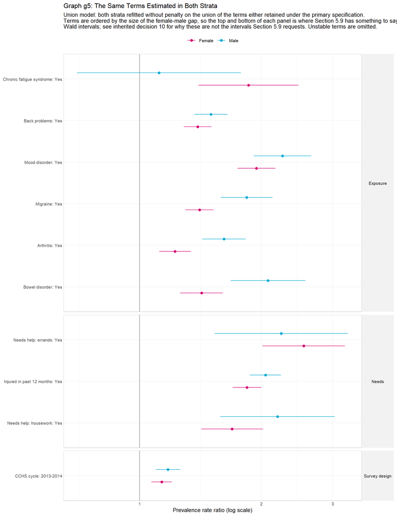

Graph g5 is Table t65 in the form that makes the comparison visible: each term appears twice, once per stratum, ordered by the size of the gap. The top and bottom of each domain panel are where Section 5.9 has something to say; the middle is where the two sexes agree.

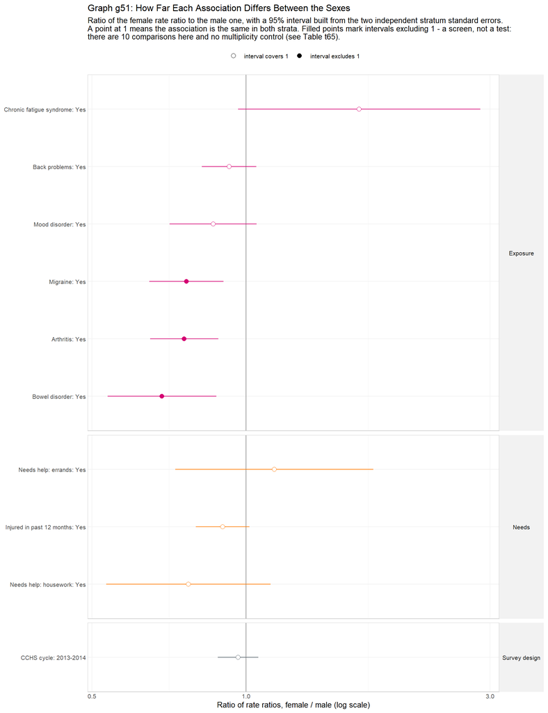

Graph g51 plots the difference itself rather than the two estimates. A point at 1 means the association is identical in the two strata; distance from 1 is the size of the sex difference and the interval is its uncertainty. The filled points are a screening device with the same caveat as Table t65 attached: with this many comparisons and no multiplicity control, some intervals will exclude 1 by construction.

Table t61: Section 5.10 metrics computed IN SAMPLE, for all eight sex-stratified models. RMSE and MAE are weighted (inherited decision 19). AIC and BIC come from a weighted pseudo-likelihood and rank models rather than measure them (inherited decision 18); ACROSS strata they are not comparable at all, because each is computed on a different sample. Read them down a stratum, never across. The held-out versions, which are the ones Section 5.10 actually asks for, are in Tables t63 and t64.

| Stratum | Specification | Role | n | Terms | AIC | BIC | McFadden R2 | Theta | RMSE | MAE | C-statistic | Comparable pairs | Converged |
| --- | --- | --- | --- | --- | --- | --- | --- | --- | --- | --- | --- | --- | --- |
| Female | Model 1 | Primary | 24,273 | 9 | 68,123 | 68,212 | 0.0196 | 0.2217 | 4.243 | 2.007 | 0.6167 | 55.4% | yes |
| Female | Model 2 | Secondary | 24,273 | 18 | 67,477 | 67,639 | 0.0291 | 0.2372 | 4.157 | 1.964 | 0.6400 | 55.4% | yes |
| Female | Model 3 | Sensitivity | 24,273 | 71 | 67,426 | 68,017 | 0.0314 | 0.2401 | 4.489 | 2.008 | 0.6525 | 55.4% | yes |
| Female | Model 4 | Sensitivity | 24,273 | 82 | 66,880 | 67,552 | 0.0395 | 0.2546 | 4.202 | 1.951 | 0.6666 | 55.4% | yes |
| Male | Model 1 | Primary | 24,659 | 8 | 54,348 | 54,429 | 0.0185 | 0.1510 | 3.689 | 1.564 | 0.6009 | 43.4% | yes |
| Male | Model 2 | Secondary | 24,659 | 16 | 53,856 | 54,002 | 0.0277 | 0.1614 | 3.970 | 1.554 | 0.6208 | 43.4% | yes |
| Male | Model 3 | Sensitivity | 24,659 | 57 | 53,873 | 54,352 | 0.0289 | 0.1624 | 4.000 | 1.581 | 0.6311 | 43.4% | yes |
| Male | Model 4 | Sensitivity | 24,659 | 53 | 53,514 | 53,961 | 0.0352 | 0.1702 | 4.537 | 1.570 | 0.6454 | 43.4% | yes |

```
Output out3: Convergence, dispersion, and empty selections
```

```
 Stratum models converged failed
  Female      4         4      0
    Male      4         4      0
```

```
No sex-stratified model failed to converge.
```

```
No specification returned an empty selection in either stratum. This is
the contrast with model-2 that justifies decision 35: at stratum scale
the parsimonious rule still has something to say, so Section 5.5's
designation of it as primary needs no amendment.
```

```
Dispersion (theta; smaller means more overdispersed):
```

```
 Stratum Specification  Theta
  Female       Model 1 0.2217
  Female       Model 2 0.2372
  Female       Model 3 0.2401
  Female       Model 4 0.2546
    Male       Model 1 0.1510
    Male       Model 2 0.1614
    Male       Model 3 0.1624
    Male       Model 4 0.1702
```

```
Theta is comparable between the strata because the weights are rescaled to
```

```
mean 1 inside each of them (decision 37). A lower theta in one stratum
```

```
means the count is more overdispersed there once the model has had its say.
```

One warning about Table t61 that it shares with model-2’s version: **the rows are not comparable across strata.** Each is computed on a different sample with a different outcome distribution, and AIC and BIC come from a weighted pseudo-likelihood on different data. Read the table down a stratum — comparing the four specifications within one sex — and never across. The dispersion parameter is the one exception, and only because decision 37 rescales the weights inside each stratum specifically to make it comparable.

Output out3 answers Section 5.9’s request that non-convergence be reported, and counts empty selections. The empty-selection count is also the direct evidence for decision 35: if the parsimonious penalty returns something in every stratum, Section 5.5’s designation of it as primary needs no amendment, and model-2’s reversal stays confined to the subgroups that motivated it.

**Review point 8**

Agree or disagree that Tables t6, t62 and t65 together are fit to serve as the study’s Table 5. Four questions:

1. Should the deliverable table carry all four specifications, or should Model 1 stand alone with the rest in an appendix?
2. Is decision 39’s union model the right basis for the female–male comparison? The alternatives — comparing the two selected models directly, or restricting to terms selected in both — are recorded with it. Both are simpler and both are more likely to be misread.
3. Should Table t65 carry any multiplicity adjustment, or is a screen presented as a screen the honest presentation? Adjusting would change what the table is for.
4. Is the `UNSTABLE` flag at a standard error of 2 on the log scale the right threshold at this sample size? It was set for model-2’s small subgroups and re-made here; at stratum scale it may be too permissive to catch anything.

## Step 9 — Section 5.10, Held-Out Performance

Section 5.10 asks for AIC, BIC, McFadden’s pseudo-$R^2$, a C-statistic, and RMSE and MAE “computed on the withheld test fold,” averaged over five folds, for each sex-stratified model. Table t61 gave the in-sample versions. This step supplies the rest.

Unlike Section 5.8, Section 5.10 does not offer leave-one-out as an alternative — which is consistent, because both strata are large. Five folds also keep model-3 on the same footing as model-1 and model-2. Decision 38.

**Five-fold cross-validation of every stratum and specification, both variants**

```r
if (!force_refit_cv && file.exists(cv_cache_path)) {
  cv_performance <- readRDS(cv_cache_path)
  cat("Loaded cached cross-validation results from ", cv_cache_path, "\n", sep = "")
} else {
  cat("Refitting the Section 5.10 cross-validation. This is the slow block.\n")
  cv_start_time <- Sys.time()

  cv_performance <- purrr::map_dfr(strata_levels, function(this_stratum) {
    sub <- strata[[this_stratum]]
    fold_id <- assign_folds(nrow(sub), perf_folds, perf_seed)
    cat("  ", this_stratum, " (n = ", nrow(sub), ")\n", sep = "")

    purrr::map_dfr(seq_len(perf_folds), function(this_fold) {
      cat("    fold ", this_fold, " of ", perf_folds, "\n", sep = "")
      test_rows <- which(fold_id == this_fold)
      train_rows <- which(fold_id != this_fold)

      # Variant A - term set fixed at what the whole stratum selected.
      fixed <- purrr::map_dfr(model_specs$spec_id, function(this_spec) {
        term_vars <- spec_terms[[paste0(this_stratum, "__", this_spec)]]
        evaluate_fold(sub, train_rows, test_rows, term_vars, outcome_var) %>%
          mutate(stratum = this_stratum, spec_id = this_spec,
                 fold = this_fold, variant = "fixed term set")
      })

      # Variant B - the whole two-stage procedure re-run inside the training
      # fold, so no held-out respondent contributed to selection. One penalised
      # fit per predictor set, shared by the two penalties that read it.
      train_frame <- droplevels(sub[train_rows, , drop = FALSE])
      fold_forced <- forced_vars[
        purrr::map_lgl(forced_vars, ~ is_informative(train_frame[[.x]]))
      ]
      fold_lassos <- purrr::map(
        stats::setNames(fit_ids, fit_ids),
        function(this_fit_id) {
          offered <- stratum_candidates(train_frame, candidate_sets[[this_fit_id]])
          design <- build_design(train_frame, c(fold_forced, offered))
          list(
            design = design,
            lasso = tryCatch(
              fit_lasso(design, train_frame[[outcome_var]],
                        train_frame$weight_scaled, lasso_seed),
              error = function(e) NULL
            )
          )
        }
      )

      reselected <- purrr::pmap_dfr(
        model_specs %>% select(spec_id, lambda_rule, fit_id),
        function(spec_id, lambda_rule, fit_id) {
          fl <- fold_lassos[[fit_id]]
          term_vars <- if (is.null(fl$lasso)) {
            fold_forced
          } else {
            kept <- coefficients_at(fl$lasso, fl$design, lambda_rule) %>%
              retained_variables()
            union(fold_forced, setdiff(kept, fold_forced))
          }
          evaluate_fold(sub, train_rows, test_rows, term_vars, outcome_var) %>%
            mutate(stratum = this_stratum, spec_id = spec_id,
                   fold = this_fold, variant = "selection re-run",
                   n_vars_selected = length(term_vars))
        }
      )

      bind_rows(fixed, reselected)
    })
  }) %>%
    left_join(model_specs %>% select(spec_id, model_label, role), by = "spec_id")

  attr(cv_performance, "elapsed_minutes") <-
    as.numeric(difftime(Sys.time(), cv_start_time, units = "mins"))
  saveRDS(cv_performance, cv_cache_path)
}

readr::write_csv(cv_performance, paste0(local_data, "cv-performance-folds.csv"))

cv_summary <- cv_performance %>%
  group_by(variant, stratum, spec_id, model_label) %>%
  summarise(
    folds_converged = sum(converged),
    n_terms_mean = mean(n_terms, na.rm = TRUE),
    n_terms_range = if (all(is.na(n_terms))) {
      "n/a"
    } else {
      paste0(min(n_terms, na.rm = TRUE), "-", max(n_terms, na.rm = TRUE))
    },
    rmse_mean = mean(rmse, na.rm = TRUE), rmse_sd = stats::sd(rmse, na.rm = TRUE),
    mae_mean = mean(mae, na.rm = TRUE), mae_sd = stats::sd(mae, na.rm = TRUE),
    mcfadden_mean = mean(mcfadden_r2, na.rm = TRUE),
    mcfadden_sd = stats::sd(mcfadden_r2, na.rm = TRUE),
    c_mean = mean(c_statistic, na.rm = TRUE), c_sd = stats::sd(c_statistic, na.rm = TRUE),
    comparable_share = mean(comparable_share, na.rm = TRUE),
    unscorable = sum(n_unscorable, na.rm = TRUE),
    .groups = "drop"
  ) %>%
  left_join(stratum_inventory %>% select(stratum, n), by = "stratum") %>%
  arrange(variant, match(stratum, strata_levels), spec_id)

readr::write_csv(cv_summary, paste0(local_data, "cv-performance-summary.csv"))
```

Table t63: Section 5.10 five-fold cross-validated performance, term set held FIXED across folds. Each cell is the mean over five folds of that stratum, with the between-fold standard deviation in parentheses. Metrics are computed on the withheld fold only, weighted (inherited decision 19). These numbers are optimistic: the LASSO that chose the term set saw every fold (inherited decision 16). Table t64 removes that advantage.

| Stratum | Specification | n | Terms | CV RMSE | CV MAE | CV McFadden R2 | CV C-statistic | Comparable pairs | Folds converged |
| --- | --- | --- | --- | --- | --- | --- | --- | --- | --- |
| Female | Model 1 | 24,273 | 9 | 4.242 (0.367) | 2.011 (0.054) | 0.0179 (0.0095) | 0.6165 (0.0225) | 55.4% | 5 / 5 |
| Female | Model 2 | 24,273 | 18 | 4.171 (0.364) | 1.975 (0.055) | 0.0257 (0.0073) | 0.6355 (0.0122) | 55.4% | 5 / 5 |
| Female | Model 3 | 24,273 | 71 | 4.523 (0.368) | 2.036 (0.045) | 0.0163 (0.0227) | 0.6340 (0.0191) | 55.4% | 5 / 5 |
| Female | Model 4 | 24,273 | 82 | 4.291 (0.320) | 1.990 (0.065) | 0.0247 (0.0178) | 0.6492 (0.0157) | 55.4% | 5 / 5 |
| Male | Model 1 | 24,659 | 8 | 3.703 (0.181) | 1.574 (0.046) | 0.0177 (0.0058) | 0.6008 (0.0065) | 43.4% | 5 / 5 |
| Male | Model 2 | 24,659 | 16 | 4.028 (0.365) | 1.573 (0.048) | 0.0247 (0.0050) | 0.6178 (0.0088) | 43.4% | 5 / 5 |
| Male | Model 3 | 24,659 | 57 | 4.133 (0.480) | 1.613 (0.078) | 0.0177 (0.0119) | 0.6179 (0.0078) | 43.4% | 5 / 5 |
| Male | Model 4 | 24,659 | 53 | 4.692 (0.761) | 1.611 (0.072) | 0.0252 (0.0083) | 0.6335 (0.0064) | 43.4% | 5 / 5 |

Table t63 is the literal answer to Section 5.10: the term set is what the whole stratum’s LASSO chose, and the negative binomial is refitted five times with a fifth of the stratum withheld each time. It is also, for that reason, optimistic — the penalty that produced the term list saw every respondent it is now being scored on.

Table t64: The same five folds, with the entire two-stage procedure re-run inside each training fold so that no held-out respondent contributed to selection. The term range is the artifact to read first: it says how far a stratum’s selected set moves when a fifth of it is withheld. model-1 found that range wide even at n = 48,932; a stratum is about half that, so a wider range here is expected and a narrow one would be the surprise.

| Stratum | Specification | n | Terms (mean) | Terms (range) | CV RMSE | CV McFadden R2 | CV C-statistic | Folds converged |
| --- | --- | --- | --- | --- | --- | --- | --- | --- |
| Female | Model 1 | 24,273 | 10 | 4-27 | 4.221 (0.372) | 0.0104 (0.0121) | 0.5891 (0.0265) | 5 / 5 |
| Female | Model 2 | 24,273 | 19 | 13-39 | 4.146 (0.347) | 0.0208 (0.0112) | 0.6274 (0.0137) | 5 / 5 |
| Female | Model 3 | 24,273 | 66 | 57-78 | 4.485 (0.358) | 0.0132 (0.0301) | 0.6330 (0.0200) | 5 / 5 |
| Female | Model 4 | 24,273 | 81 | 75-87 | 4.313 (0.375) | 0.0223 (0.0225) | 0.6480 (0.0156) | 5 / 5 |
| Male | Model 1 | 24,659 | 9 | 8-12 | 4.200 (1.288) | 0.0170 (0.0058) | 0.6014 (0.0097) | 5 / 5 |
| Male | Model 2 | 24,659 | 16 | 15-18 | 4.824 (2.049) | 0.0242 (0.0055) | 0.6172 (0.0088) | 5 / 5 |
| Male | Model 3 | 24,659 | 53 | 40-65 | 4.034 (0.440) | 0.0159 (0.0117) | 0.6154 (0.0108) | 5 / 5 |
| Male | Model 4 | 24,659 | 45 | 31-61 | 4.777 (1.014) | 0.0208 (0.0098) | 0.6289 (0.0098) | 5 / 5 |

Table t64 removes that advantage by re-running the whole two-stage procedure inside each training fold. The term-count range is the column to read first. Model 1 found the selected set unstable even at $n = 48{,}932$, ranging from eight to thirty-eight terms across folds; a stratum is about half that, so a wider range here is the expected result and a narrow one would be the surprise.

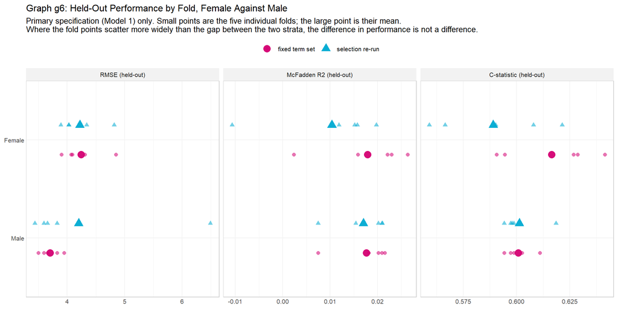

Graph g6 shows the five folds individually rather than only their mean, for the primary specification. The comparison it is built for is between the *spread* of the folds and the *gap* between the two strata. Where the fold points scatter more widely than the strata differ, a difference in held-out performance between the sexes is not a difference, and the means printed in Tables t63 and t64 should not be set side by side without that qualification.

```
Output out6: Reading the C-statistic, and the size of the selection optimism
```

```
Share of respondents at zero days, by stratum:
```

```
 Stratum Zero days
  Female     64.5%
    Male     74.1%
```

```
Harrell's C counts a pair only when the two respondents differ on the
```

```
outcome. Most respondents in both strata report zero days, so most pairs
```

```
are incomparable and never enter the denominator. Table t63 reports the
```

```
comparable share beside every C for exactly this reason, and the female
```

```
and male C-statistics should be compared only alongside those shares.
```

```
Selection optimism (fixed minus re-run), primary specification:
```

```
 Stratum      n  d RMSE d McFadden     d C
  Female 24,273 +0.0211    +0.0076 +0.0274
    Male 24,659 -0.4970    +0.0007 -0.0005
```

```
A positive d McFadden or d C is the amount by which evaluating a model on
```

```
data that helped select it flatters that model. model-1 found this quantity
```

```
to be essentially zero at n = 48,932; a stratum is about half that, so the
```

```
same reassurance should be earned rather than assumed.
```

```
Term-set instability under refitting, all four specifications:
```

```
Both columns count DESIGN COLUMNS, not variables, so that the full-stratum
```

```
fit and the fold refits are measured on the same scale.
```

```
 Stratum Specification Full-stratum columns Across folds (mean) Across folds (range)
  Female       Model 1                    9                10.2                 4-27
  Female       Model 2                   18                18.8                13-39
  Female       Model 3                   71                65.8                57-78
  Female       Model 4                   82                80.6                75-87
    Male       Model 1                    8                 9.4                 8-12
    Male       Model 2                   16                16.2                15-18
    Male       Model 3                   57                52.6                40-65
    Male       Model 4                   53                45.2                31-61
```

```
  cross-validation runtime: 4.7 minutes
```

**The C-statistic needs its comparable-pairs share**

Harrell’s C counts only pairs of respondents who differ on the outcome. Most respondents in both strata report zero days, so most pairs are incomparable and never enter the denominator — and the share that does enter is not the same in the two strata, because the strata do not have the same proportion of respondents with a non-zero outcome. A female and a male C-statistic are therefore computed over different fractions of their respective samples, and comparing them without the comparable-pairs share beside each is not a valid comparison. Table t63 reports the share on every row for exactly this reason.

**Review point 9**

Three questions.

1. Which table is the Section 5.10 deliverable — t63, which follows the proposal’s wording, or t64, which is what the numbers would be on new data? Model 1 found the gap negligible; whether that holds at stratum scale is what out6 measures, and the answer should decide this.
2. Does the term-count range in t64 change how a sex-specific variable list may be described in the manuscript? If the selected set moves substantially under refitting, the honest sentence is about the estimates in Table t65 rather than about the identity of either stratum’s selected set.
3. Should the female and male models be compared on held-out performance at all? Section 5.10 asks for the metrics per model and does not ask for the comparison; Graph g6 supplies it because the question is natural, but the comparable-pairs problem means it is easy to over-read.

## Step 10 — Reproducibility Ledger

Every fitted object and every intermediate table is written to disk, so a reviewer can re-open any result without re-running the estimation, and so that downstream reports can cite these artifacts as fixed rather than recompute them.

Table t7: Artifact manifest. Every persisted object, with the call that reloads it. These files are the versioned evidentiary record for Sections 5.9 and 5.10; downstream reports should read them rather than re-estimate.

| Artifact | Kind | Size | Reload with |
| --- | --- | --- | --- |
| data-local/composition-balance.csv | derived table | 18.33K | readr::read_csv(‘data-local/composition-balance.csv’) |
| data-local/condition-prevalence-by-sex.csv | derived table | 1.91K | readr::read_csv(‘data-local/condition-prevalence-by-sex.csv’) |
| data-local/cv-performance-folds.csv | derived table | 18.06K | readr::read_csv(‘data-local/cv-performance-folds.csv’) |
| data-local/cv-performance-summary.csv | derived table | 3.82K | readr::read_csv(‘data-local/cv-performance-summary.csv’) |
| data-local/decision-registry.csv | derived table | 6.31K | readr::read_csv(‘data-local/decision-registry.csv’) |
| data-local/model-comparison.csv | derived table | 1.93K | readr::read_csv(‘data-local/model-comparison.csv’) |
| data-local/nb-coefficients.csv | derived table | 122.6K | readr::read_csv(‘data-local/nb-coefficients.csv’) |
| data-local/selection-counts.csv | derived table | 526 | readr::read_csv(‘data-local/selection-counts.csv’) |
| data-local/selection-long.csv | derived table | 95.46K | readr::read_csv(‘data-local/selection-long.csv’) |
| data-local/selection-matrix.csv | derived table | 2.93K | readr::read_csv(‘data-local/selection-matrix.csv’) |
| data-local/sex-heterogeneity.csv | derived table | 5.18K | readr::read_csv(‘data-local/sex-heterogeneity.csv’) |
| data-local/stratum-feasibility.csv | derived table | 504 | readr::read_csv(‘data-local/stratum-feasibility.csv’) |
| data-local/stratum-inventory.csv | derived table | 320 | readr::read_csv(‘data-local/stratum-inventory.csv’) |
| data-local/table-5-sex-stratified-models.csv | derived table | 15.37K | readr::read_csv(‘data-local/table-5-sex-stratified-models.csv’) |
| data-local/union-coefficients.csv | derived table | 7.4K | readr::read_csv(‘data-local/union-coefficients.csv’) |
| data-local/fits/cv-performance.rds | fitted object | 4.98K | readRDS(‘data-local/fits/cv-performance.rds’) |
| data-local/fits/cv_Female__exclude.rds | fitted object | 39.13K | readRDS(’data-local/fits/cv_Female__exclude.rds’) |
| data-local/fits/cv_Female__include.rds | fitted object | 44.7K | readRDS(’data-local/fits/cv_Female__include.rds’) |
| data-local/fits/cv_Male__exclude.rds | fitted object | 38.88K | readRDS(’data-local/fits/cv_Male__exclude.rds’) |
| data-local/fits/cv_Male__include.rds | fitted object | 43.19K | readRDS(’data-local/fits/cv_Male__include.rds’) |
| data-local/fits/map_Female__exclude.rds | fitted object | 1.67K | readRDS(’data-local/fits/map_Female__exclude.rds’) |
| data-local/fits/map_Female__include.rds | fitted object | 1.83K | readRDS(’data-local/fits/map_Female__include.rds’) |
| data-local/fits/map_Male__exclude.rds | fitted object | 1.67K | readRDS(’data-local/fits/map_Male__exclude.rds’) |
| data-local/fits/map_Male__include.rds | fitted object | 1.83K | readRDS(’data-local/fits/map_Male__include.rds’) |
| data-local/fits/nb_Female__model_1.rds | fitted object | 3.15M | readRDS(’data-local/fits/nb_Female__model_1.rds’) |
| data-local/fits/nb_Female__model_2.rds | fitted object | 4.86M | readRDS(’data-local/fits/nb_Female__model_2.rds’) |
| data-local/fits/nb_Female__model_3.rds | fitted object | 14.69M | readRDS(’data-local/fits/nb_Female__model_3.rds’) |
| data-local/fits/nb_Female__model_4.rds | fitted object | 16.67M | readRDS(’data-local/fits/nb_Female__model_4.rds’) |
| data-local/fits/nb_Male__model_1.rds | fitted object | 3M | readRDS(’data-local/fits/nb_Male__model_1.rds’) |
| data-local/fits/nb_Male__model_2.rds | fitted object | 4.54M | readRDS(’data-local/fits/nb_Male__model_2.rds’) |
| data-local/fits/nb_Male__model_3.rds | fitted object | 12.31M | readRDS(’data-local/fits/nb_Male__model_3.rds’) |
| data-local/fits/nb_Male__model_4.rds | fitted object | 11.56M | readRDS(’data-local/fits/nb_Male__model_4.rds’) |
| data-local/fits/nb_nulls.rds | fitted object | 3M | readRDS(‘data-local/fits/nb_nulls.rds’) |
| data-local/fits/nb_union.rds | fitted object | 6.71M | readRDS(‘data-local/fits/nb_union.rds’) |

```
Output out4: Reproducibility parameters and residual scope
```

```
  seed:                     42
```

```
  penalty CV folds:         5
```

```
  performance CV folds:    5 (seed 42)
```

```
  outcome:                  days_absent_total
```

```
  weight:                   wts_m_pooled  (rescaled to mean 1 within each stratum)
```

```
  forced-in terms:          cchs_cycle_f
```

```
  stratifying variable:     sex
```

```
  source parquet:           ./data-private/derived/cchs-2-tables/cchs_analytic.parquet
```

```
  analytic frame n:         48,932
```

```
  Female stratum n:         24,273
```

```
  Male stratum n:           24,659
```

```
  penalised fits:           4
```

```
  models estimated:        8 of 8
```

```
  union models:            2 of 2 (10 terms)
```

```
  heterogeneity rows:       10
```

```
Proposal sections model-3 closes:
```

```
  - Section 5.9 sex-stratified multivariable models (Table 5 = t6 / t62)
```

```
  - Section 5.10 model performance evaluation (t61 in-sample, t63 / t64 held out)
```

```
Requirements NOT met, and why:
```

```
  - Bootstrap variance estimation (inherited decision 10: replicate weights
```

```
    absent from the PUMF). Sandwich and Kish-inflated intervals stand in as
```

```
    lower bounds, exactly as in model-00, model-1 and model-2.
```

```
  - Section 5.1 Little's MCAR test and multiple imputation are not performed.
```

```
  - The female-male comparison of Table t65 is a screen, not a confirmatory
```

```
    test: no multiplicity control, and every row inherits the selection step
```

```
    that produced the union term set (decision 39).
```

```
With model-3, every modelling section of the proposal has an estimation of
```

```
record: 5.3 in model-00, 5.4 to 5.6 in model-1, 5.7 to 5.8 in model-2, and
```

```
5.9 to 5.10 here. Downstream reports should read the artifacts in Table t7
```

```
rather than re-estimate.
```

# What Model 3 Settles, and What It Does Not

**Not settled.**

- *Variance estimation.* Inherited decision 10 is data-blocked. The sandwich and Kish intervals bracket the understatement from below; neither is the quantity Section 5.9 specifies. Delivering it requires Research Data Centre access.
- *Gender.* Neither cycle carries a gender item, so a gender-stratified analysis is not available from these files at any level of effort.
- *The sex differences themselves.* Table t65 ranks candidates; it does not certify any of them. Every row carries the selection step in its interval and none carries a multiplicity adjustment. Confirming a specific sex difference is a pre-registered, single-hypothesis exercise that these data can motivate but not complete.
- *Composition versus association.* Where a sex difference coincides with a prevalence difference in Table t21, the two explanations are not separated here. Separating them requires a reweighting or decomposition analysis that answers a different question from the one Section 5.9 asks.
- *Section 5.1.* Little’s MCAR test and multiple imputation are not performed; complete-case analysis stands in, inherited from model-1 along with its cost.
- *Model adequacy inside strata.* Whether a negative binomial is the right likelihood for a stratum outcome that is still majority zeros is not tested here, any more than it was in model-1 or model-2. Calibration, rootograms and hurdle alternatives belong to a dedicated evaluation report reading the artifacts in Step 10.

**How to use this report.** Model 3 is the estimation of record for Sections 5.9 and 5.10. With it, every modelling section of the proposal has an estimation of record: 5.3 in model-00, 5.4 to 5.6 in model-1, 5.7 to 5.8 in model-2, and 5.9 to 5.10 here. Reports that follow should load the objects in Table t7 and interpret them; re-estimating would produce a second set of numbers with no better claim to authority and a real chance of drifting from these.

# Session Information

```
Rendered at:      2026-08-03 10:29:10
```

```
Render duration:  52.4 seconds
```